This notebook was created as part of the Master project: 'Safe and Sustainable by design: environmental fate of phosphorus compounds'.

By Hannah Flerlage, University of Amsterdam, January-December 2020. Email: hannah.flerlage@posteo.de

This is the 2. of 3 notebooks for the systematic, computer-aided approach to redesigning chemicals developed in the project.

# 2. Prediction of properties: QSAR model results analysis

## Packages and working dir

```python
import os
import subprocess
import pandas as pd
import numpy as np
import math
import time
from IPython.display import Image
from functools import reduce

from rdkit import Chem
from rdkit.Chem.Draw import IPythonConsole
from rdkit.Chem import Draw
from rdkit.Chem import PandasTools
from itertools import groupby

from rdkit.Chem.Draw import MolsToGridImage
from rdkit.Chem.Draw.MolDrawing import DrawingOptions
DrawingOptions.includeAtomNumbers=True

import matplotlib.pyplot as plt
from matplotlib import rc
```

```python
Projectdir = "C:\\Users\\Hannah\\Documents\\Master UvA\\master project\\OMG"
os.chdir(Projectdir)
print("Current Working Directory: " , os.getcwd())
```

```
Current Working Directory:  C:\Users\Hannah\Documents\Master UvA\master project\OMG
```

## General functions

```python
def get_df_name(df):
    '''returns the name of the variable in which the df is stored as a string'''
    name =[x for x in globals() if globals()[x] is df][0]
    return name

def swaprowsdf(a,row1, row2):
    '''swaps row1 with row2 in df a'''
    b, c = a.iloc[row1].copy(), a.iloc[row2].copy()
    a.iloc[row1],a.iloc[row2] = c,b
    return a

def checkIfDuplicates(listOfElems):
    ''' Check if given list contains any duplicates '''
    for elem in listOfElems:
        if listOfElems.count(elem) > 1:
            print('doubles')
            return True
    print('no doubles')
    return False

def show_mol_grid(mols):
    '''draws molecules in grid, needs to be last command in cell'''
    return MolsToGridImage(mols
        , subImgSize=(250,200)
        ,molsPerRow=3
    )

def drawsmileslist(smileslist):
    '''draws molecules from list of smiles in grid, needs to be last command in cell'''
    mols = []
    for smiles in smileslist:
        mols.append(Chem.MolFromSmiles(smiles))
    return(show_mol_grid(mols)
    )

def writetxt(alist, name, outfolder = os.getcwd()):
    '''writes a list to a txt with every element in list in next line, input name without ending'''
    with open(os.path.join(outfolder,(str(name)+'.txt')), 'w') as f:
        for item in alist:
            f.write("%s\n" % item)


def replacesquare(smileslist, old, new):
    '''replaces old string with new string in every smiles of smileslist'''
    return([sub.replace(old, new) for sub in smileslist])

def nosquaretxt(squaretxt, outname, outfolder = os.getcwd()):
    '''Replaces [PH] with P in .txt to create compatible input for EpiSuite'''
    squarelist = [line.rstrip('\n') for line in open(squaretxt,'r')]
    nosquare = replacesquare(squarelist,'[PH]','P')
    writetxt(nosquare,outname, outfolder)
    print('[PH] replaced with P in ',outname , '.txt in ',outfolder)
    return

def nosquaretxtS(squaretxt, outname, outfolder = os.getcwd()):
    '''Replaces [SH] with S in .txt to create compatible input for EpiSuite'''
    squarelist = [line.rstrip('\n') for line in open(squaretxt,'r')]
    nosquare = replacesquare(squarelist,'[SH]','S')
    writetxt(nosquare,outname, outfolder)
    print('[SH] replaced with S in ',outname , '.txt in ',outfolder)
    return

def jointxts(filenameslist, outname, outfolder=(Projectdir + '\\SMILESOMGout'),
             infolder=(Projectdir + '\\SMILESOMGout')):
    '''joins txts whose names are specified in a list into on txt with specified name. Folder where to find txts
    and folder where to store joined txt can be specified '''
    #filenameslist is list of files in infolder, outname is name of outputfile in outfolder
    with open(os.path.join(outfolder,(str(outname)+'.txt')), 'w') as outfile:
        for fname in filenameslist:
            with open(os.path.join(infolder, str(fname))) as infile:
                for line in infile:
                    outfile.write(line)
```

## Functions for analysis of model results

```python
def biowin_better_than_original_show(dfnew, column, original, dforiginal):
    '''draws molecules from newdf which perform btter than original in specified column'''
    df = dfnew[dfnew[column].astype(float) > float(dforiginal.at[0,column])]
    df.dropna
    print('Better than ', original, ' in', column, ':\n', len(df.index) )
    if df.empty:
        print('DataFrame is empty, ',original,' scores (equal or) better!')
    else:
        return(drawsmileslist(df['SMILES']))

def biowin_better_than_original(dfnew, column, original, dforiginal):
    '''returns molecules from newdf which perform btter than original in specified column'''
    df = dfnew[dfnew[column].astype(float) > float(dforiginal.at[0,column])]
    df.dropna
    print('Better than ', original, ' in', column, ':\n' , len(df.index))
    if df.empty:
        print('DataFrame is empty, ',original,' scores (equal or) better!')
    else:
        return(df)

def higher_than_original(dfnew, column, original, dforiginal):
    '''returns molecules from newdf which perform better (higher value) than original in specified column'''
    df = dfnew[dfnew[column].astype(float) > float(dforiginal.at[0,column])]
    df.dropna
    print('Higher value than ', original, ' in', column, ':\n' , len(df.index))
    if df.empty:
        print('DataFrame is empty, ',original,' scores (equal or) better!')
    else:
        return(df)

def lower_than_original(dfnew, column, original, dforiginal):
    '''returns molecules from newdf which have lower value than original in specified column'''
    df = dfnew[dfnew[column].astype(float) < float(dforiginal.at[0,column])]
    df.dropna
    print('Lower value than ', original, ' in', column, ':\n' , len(df.index))
    if df.empty:
        print('DataFrame is empty, ',original,' no molecules with lower values!')
    else:
        return(df)

#Ready biodegradability cut-off values as defined in Biowin manual
readyBw3 = 3.25
readyBw5 = 0.5 #>=

def ready_biodegradable_show(dfnew):
    '''shows molecules from dataframe which qualify as ready biodegradable'''
    df = dfnew[(dfnew['Biowin3'].astype(float) >= readyBw3) & (dfnew['Biowin5'].astype(float) >= readyBw5) ]
    df.dropna
    df.sort_values('Biowin3', ascending=False)
    #print(df)
    if df.empty:
        print('DataFrame is empty, no ready biodegradable molecules')
    else:
        print(len(df.index),'ready biodegradable molecules in table, out of ',len(dfnew.index),'total')
        print('Ready biodegradable:\n' )
        return(drawsmileslist(df['SMILES']))

def ready_biodegradable(dfnew):
    '''returns df with those molecules which are ready biodegradable'''
    df = dfnew[(dfnew['Biowin3'].astype(float) >= readyBw3) & (dfnew['Biowin5'].astype(float) >= readyBw5) ]
    df.dropna
    df.sort_values('Biowin3', ascending=False)
    #print(df)
    if df.empty:
        print('DataFrame is empty, no ready biodegradable molecules')
    else:
        print(len(df.index),'ready biodegradable molecules in table, out of ',len(dfnew.index),'total')
        print('Ready biodegradable:\n' )
        return(df)

##### filter out subgroup containing mols#############

def smilestomollist(smileslist):
    '''creates a list of mols from a list of SMILES'''
    mollist = []
    for smiles in smileslist:
        mol = Chem.MolFromSmiles(smiles)
        mollist.append(mol)
    return(mollist)

#smarts codes for OH, N and ethers
OHsmarts = '[OX2H]'
Nsmarts = '[N]'
Ethersmarts = '[OD2]([#6])[#6]'

def filteroutSmartsbool(mollist, Smarts):
    '''input list of rd-mols! Filters out molecules with specified smarts code'''
    pattern = Chem.MolFromSmarts(Smarts)
    molsfiltered = 0
    newlist = []
    for mol in mollist:
        if mol.HasSubstructMatch(pattern):
            molsfiltered += 1
            newlist.append(False)
        else:
            newlist.append(True)
    print(molsfiltered,'structures with specified substructure (smarts) were filtered out.')
    return(newlist)

def filterinSmartsbool(mollist, Smarts):
    '''input list of rd-mols! Filters molecules with specified smarts code'''
    pattern = Chem.MolFromSmarts(Smarts)
    molsfiltered = 0
    newlist = []
    for mol in mollist:
        if mol.HasSubstructMatch(pattern):
            molsfiltered += 1
            newlist.append(True)
        else:
            newlist.append(False)
    print(molsfiltered,'structures with specified substructure (smarts) were selected.')
    return(newlist)


def filteroutSmartsdf(dfin, smarts):
    '''returns new df with molecules from df without OH-groups'''
    df = dfin[filteroutSmartsbool(smilestomollist(dfin['SMILES']),smarts)]
    df.dropna
    print('Molecules without specified group in new DataFrame: ', len(df.index))
    if df.empty:
        print('DataFrame is empty, all molecules contained group')
    else:
        return(df)

def filterinSmartsdf(dfin, smarts):
    '''returns new df with molecules from df without OH-groups'''
    df = dfin[filterinSmartsbool(smilestomollist(dfin['SMILES']),smarts)]
    df.dropna
    print('Molecules without specified group filtered out: ', len(dfin.index) - len(df.index))
    if df.empty:
        print('DataFrame is empty, no molecules contained group')
    else:
        return(df)
```

## Episuite building/validation data

from manual, the data is available here: http://esc.syrres.com/interkow/EpiSuiteData_ISIS_SDF.htm  
Updated on September 15, 2010  
Accessed on July 13, 2020, 18:30

```python
os.chdir(Projectdir + "\\EPI_SDF_Data")
BiowinData = Chem.SDMolSupplier('EPI_Biowin_Data_SDF.sdf') #training and test data sets of the biowin model
```

```
Errors encountered:  6  ,probably NoneType errors from input sdf file.
Molecules containing a phosphoester moeiety: 20
Molecules containing at least one P: 45
Total number of molecules in BiowinData: 1263
```

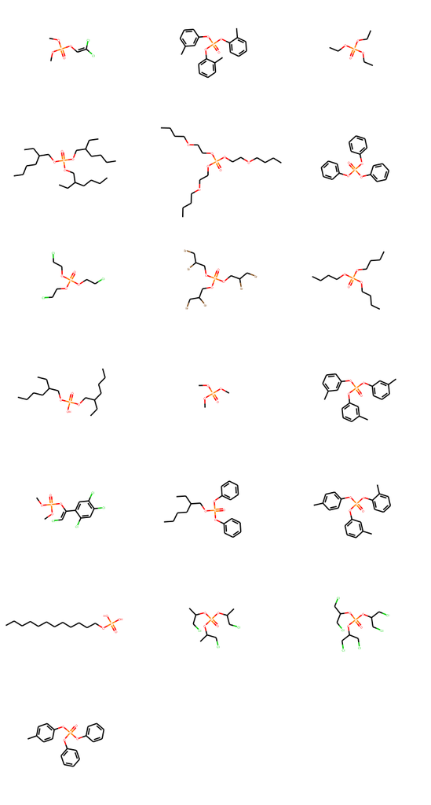

```python
phosphoester = Chem.MolFromSmarts("[$(P(=[OX1])([OX2][#6])([$([OX2H]),$([OX1-]),$([OX2][#6])])[$([OX2H]),$([OX1-]),$([OX2][#6]),$([OX2]P)]),$([P+]([OX1-])([OX2][#6])([$([OX2H]),$([OX1-]),$([OX2][#6])])[$([OX2H]),$([OX1-]),$([OX2][#6]),$([OX2]P)])]")
P = Chem.MolFromSmarts("[P]")
S = Chem.MolFromSmarts("[S]")

nPester = 0
nP = 0
nerrors = 0
phosphosmiles = []
Psmiles = []
for mol in BiowinData:
    try:
        if mol.HasSubstructMatch(phosphoester):
            nPester += 1
            phosphosmiles.append(Chem.MolToSmiles(mol))
        if mol.HasSubstructMatch(P): #and mol.HasSubstructMatch(S):
            nP += 1
            Psmiles.append(Chem.MolToSmiles(mol))
    except:
        nerrors += 1
print('Errors encountered: ', nerrors,
      ' ,probably NoneType errors from input sdf file. \nMolecules containing a phosphoester moeiety:', nPester)
print('Molecules containing at least one P:', nP)
print('Total number of molecules in BiowinData:', len(BiowinData))

drawsmileslist((phosphosmiles[:15]+phosphosmiles[16:])) #molecule 16 in this list, a linear triC18phosphoester is too bigto draw
#drawsmileslist((Psmiles))
```

**Conclusions:**  
There are at least 20 phosphoester containing molecules in the Biowin model training and validation sets. Some of them have a high similarity to tibp, for example tnbp, triethylphosphate, trimethylphosphate, triC18phosphoester linear, etc.

▶ It looks like there is sufficient similarity in the chemical strucutres used to derive the model and the structures I am generating to be operating in a valid area, at least with respect to tibp.  
5060 has a slightly more complicated structure, which is not represented here. There are 15 molecules containing both P and S.

## VEGA validity check

Datasets for the individual models used in the Mutagenicity concensus model can be found in the manual.

```python
QSARdir = "C:\\Users\\Hannah\\Documents\\Master UvA\\master project\\QSAR"
os.chdir(QSARdir)
caesar = pd.read_csv('dataset_MUTA_CAESAR.txt', sep='\t') #training and test data sets of the caesar model
ISS = pd.read_csv('dataset_MUTA_ISS.txt', sep='\t') #training and test data sets of the ISS model
KNN = pd.read_csv('dataset_MUTA_KNN.txt', sep='\t') #training and test data sets of the KNN model
SARPY = pd.read_csv('dataset_MUTA_SARPY.txt', sep='\t') #training and test data sets of the SARPY model


def molslistt(df):
    out_mols = []
    for smiles in df['SMILES']:
        mol = Chem.MolFromSmiles(smiles)
        out_mols.append(mol)
    return out_mols

caesar_mols = molslistt(caesar)
ISS_mols = molslistt(ISS)
KNN_mols = molslistt(KNN)
SARPY_mols = molslistt(SARPY)
alllist= caesar_mols + ISS_mols + KNN_mols +SARPY_mols
VEGA_molset = set(alllist)
```

```
Caesar
Errors encountered:  0  ,probably NoneType errors from input file.
Molecules containing a phosphoester moeiety: 42
Molecules containing at least one P: 102
Total number of molecules in dataset: 4204
ISS
Errors encountered:  0  ,probably NoneType errors from input file.
Molecules containing a phosphoester moeiety: 8
Molecules containing at least one P: 29
Total number of molecules in dataset: 670
KNN
Errors encountered:  6  ,probably NoneType errors from input file.
Molecules containing a phosphoester moeiety: 42
Molecules containing at least one P: 117
Total number of molecules in dataset: 5770
SARPY
Errors encountered:  0  ,probably NoneType errors from input file.
Molecules containing a phosphoester moeiety: 42
Molecules containing at least one P: 102
Total number of molecules in dataset: 4204
all together, VEGA
Errors encountered:  1  ,probably NoneType errors from input file.
Molecules containing a phosphoester moeiety: 134
Molecules containing at least one P: 350
Total number of molecules in dataset: 14843
```

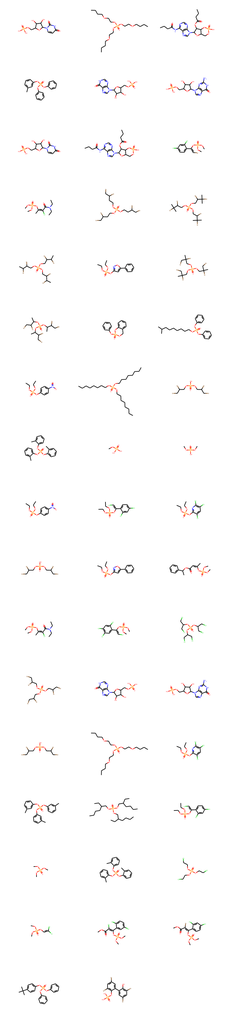

```python
def CheckValidity(molset):
    phosphoester = Chem.MolFromSmarts("[$(P(=[OX1])([OX2][#6])([$([OX2H]),$([OX1-]),$([OX2][#6])])[$([OX2H]),$([OX1-]),$([OX2][#6]),$([OX2]P)]),$([P+]([OX1-])([OX2][#6])([$([OX2H]),$([OX1-]),$([OX2][#6])])[$([OX2H]),$([OX1-]),$([OX2][#6]),$([OX2]P)])]")
    P = Chem.MolFromSmarts("[P]")
    S = Chem.MolFromSmarts("[S]")

    nPester = 0
    nP = 0
    nerrors = 0
    phosphosmiles = []
    Psmiles = []
    for mol in molset:
        try:
            if mol.HasSubstructMatch(phosphoester):
                nPester += 1
                phosphosmiles.append(Chem.MolToSmiles(mol))
            if mol.HasSubstructMatch(P): #and mol.HasSubstructMatch(S):
                nP += 1
                Psmiles.append(Chem.MolToSmiles(mol))
        except:
            nerrors += 1
    print('Errors encountered: ', nerrors,
          ' ,probably NoneType errors from input file. \nMolecules containing a phosphoester moeiety:', nPester)
    print('Molecules containing at least one P:', nP)
    print('Total number of molecules in dataset:', len(molset))

    return drawsmileslist((phosphosmiles))
    #drawsmileslist((Psmiles))
print('Caesar')
CheckValidity(caesar_mols)
print('ISS')
CheckValidity(ISS_mols)
print('KNN')
CheckValidity(KNN_mols)
print('SARPY')
CheckValidity(SARPY_mols)
print('all together, VEGA')
CheckValidity(VEGA_molset)
```

Conclusions: There are organophosphate molecules in the datasets of all models. They should thus be applicable for this work

## Biowin

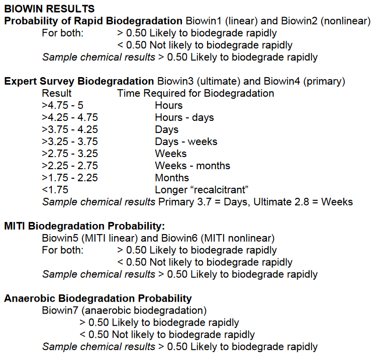

```python
Image(filename = Projectdir + "\\biowinmanual.png", width=500, height=500)
```

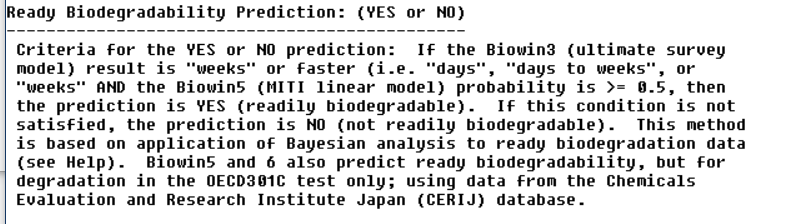

```python
Image(filename = Projectdir + "\\readybiodeg.png", width=500, height=500)
```

### Threshold: Biowin results for tibp

```python
#import the output file of the Biowin models for tibp
tibpbiowin = pd.read_csv(Projectdir + '\\tibp\\tibpbiowinall.txt',
                         sep="\t", header=None,
                         names=["Biowin1", "Biowin2","Biowin3", "Biowin4","Biowin5","Biowin6","Biowin7","SMILES"])
tibpbiowin
```

|  | Biowin1 | Biowin2 | Biowin3 | Biowin4 | Biowin5 | Biowin6 | Biowin7 | SMILES |
| --- | --- | --- | --- | --- | --- | --- | --- | --- |
| 0 | 0.9347 | 1.0 | 2.7644 | 3.9289 | 0.0732 | 0.0509 | 0.4661 | CC(C)COP(=O)(OCC(C)C)OCC(C)C |

## First series: alkyl extension run on Stevens PC

Structure generation:

OMG, using my code

run on Stevens computer

C4 to C17

```python
os.chdir(Projectdir +'\\run by steven')

OMGS1C17SMILES = pd.read_csv('allsmilesS1C17.txt', sep="\t", header=None,
                                names=["SMILES"])
#drawsmileslist(list(OMGS1C17SMILES['SMILES'])[:10])#draws the first ten smiles
```

```python
#import biowin model output
os.chdir(Projectdir +'\\run by Steven\\OMGSbiowin')

S1C17biowin = pd.read_csv('allsmilesS1C17_biowin.txt', sep="\t", header=None,
                          names=["Biowin1", "Biowin2","Biowin3", "Biowin4","Biowin5","Biowin6","Biowin7","SMILES"])

os.chdir(Projectdir)
```

```python
#show top 10 according to Biowin 1
top10s1c17 = S1C17biowin.nlargest(20,'Biowin1')[:10]
top10s1c17
```

|  | Biowin1 | Biowin2 | Biowin3 | Biowin4 | Biowin5 | Biowin6 | Biowin7 | SMILES |
| --- | --- | --- | --- | --- | --- | --- | --- | --- |
| 170058 | 1.3350 | 1.0 | 3.8027 | 4.9039 | 0.4099 | 0.2839 | -0.0801 | CCCCOP(=O)(OCCCC)OC(CCCC)CCCC |
| 2479 | 1.2600 | 1.0 | 3.6594 | 4.7361 | 0.5205 | 0.4729 | 0.4051 | CCCCOP(=O)(OCCCC)OCCCC |
| 6648 | 1.2533 | 1.0 | 3.6284 | 4.7158 | 0.5282 | 0.4790 | 0.4311 | CCCCCOP(=O)(OCCCC)OCCCC |
| 13173 | 1.2466 | 1.0 | 3.5974 | 4.6956 | 0.3868 | 0.2692 | 0.1597 | CCCCOP(=O)(OC)OC(CCCC)CCCC |
| 16244 | 1.2466 | 1.0 | 3.5974 | 4.6956 | 0.3868 | 0.2692 | 0.1597 | CCCCOP(=O)(OCCCC)OC(C)CCCC |
| 16984 | 1.2466 | 1.0 | 3.5974 | 4.6956 | 0.5359 | 0.4852 | 0.4571 | CCCCCOP(=O)(OCCCC)OCCCCC |
| 16986 | 1.2466 | 1.0 | 3.5974 | 4.6956 | 0.5359 | 0.4852 | 0.4571 | CCCCCCOP(=O)(OCCCC)OCCCC |
| 33042 | 1.2400 | 1.0 | 3.5664 | 4.6753 | 0.3945 | 0.2741 | 0.1857 | CCCCCOP(=O)(OC)OC(CCCC)CCCC |
| 33044 | 1.2400 | 1.0 | 3.5664 | 4.6753 | 0.3945 | 0.2741 | 0.1857 | CCCCCC(CCCC)OP(=O)(OC)OCCCC |
| 38500 | 1.2400 | 1.0 | 3.5664 | 4.6753 | 0.3945 | 0.2741 | 0.1857 | CCCCOP(=O)(OC)OCC(CCCC)CCCC |

```python
ready_biodegradable(S1C17biowin)
```

```
52 ready biodegradable molecules in table, out of  296223 total
Ready biodegradable:
```

|  | Biowin1 | Biowin2 | Biowin3 | Biowin4 | Biowin5 | Biowin6 | Biowin7 | SMILES |
| --- | --- | --- | --- | --- | --- | --- | --- | --- |
| 380 | 1.1649 | 1.0 | 3.4230 | 4.5075 | 0.5052 | 0.4607 | 0.6709 | CCCCOP(=O)(OCC)OCCCC |
| 406 | 1.1649 | 1.0 | 3.4230 | 4.5075 | 0.5052 | 0.4607 | 0.6709 | CCCCCOP(=O)(OC)OCCCC |
| 930 | 1.1582 | 1.0 | 3.3920 | 4.4872 | 0.5128 | 0.4668 | 0.6968 | CCCCCOP(=O)(OC)OCCCCC |
| 934 | 1.1582 | 1.0 | 3.3920 | 4.4872 | 0.5128 | 0.4668 | 0.6968 | CCCCCCOP(=O)(OC)OCCCC |
| 1034 | 1.1582 | 1.0 | 3.3920 | 4.4872 | 0.5128 | 0.4668 | 0.6968 | CCCCOP(=O)(OCCC)OCCCC |
| 1042 | 1.1582 | 1.0 | 3.3920 | 4.4872 | 0.5128 | 0.4668 | 0.6968 | CCCCCOP(=O)(OCC)OCCCC |
| 2286 | 1.1516 | 1.0 | 3.3610 | 4.4670 | 0.5205 | 0.4729 | 0.7228 | CCCCCCOP(=O)(OC)OCCCCC |
| 2288 | 1.1516 | 1.0 | 3.3610 | 4.4670 | 0.5205 | 0.4729 | 0.7228 | CCCCCCCOP(=O)(OC)OCCCC |
| 2433 | 1.1516 | 1.0 | 3.3610 | 4.4670 | 0.5205 | 0.4729 | 0.7228 | CCCCCOP(=O)(OCC)OCCCCC |
| 2434 | 1.1516 | 1.0 | 3.3610 | 4.4670 | 0.5205 | 0.4729 | 0.7228 | CCCCCCOP(=O)(OCC)OCCCC |
| 2479 | 1.2600 | 1.0 | 3.6594 | 4.7361 | 0.5205 | 0.4729 | 0.4051 | CCCCOP(=O)(OCCCC)OCCCC |
| 2480 | 1.1516 | 1.0 | 3.3610 | 4.4670 | 0.5205 | 0.4729 | 0.7228 | CCCCCOP(=O)(OCCC)OCCCC |
| 5971 | 1.1449 | 1.0 | 3.3300 | 4.4468 | 0.5282 | 0.4790 | 0.7488 | CCCCCCOP(=O)(OC)OCCCCCC |
| 5972 | 1.1449 | 1.0 | 3.3300 | 4.4468 | 0.5282 | 0.4790 | 0.7488 | CCCCCCCOP(=O)(OC)OCCCCC |
| 5986 | 1.1449 | 1.0 | 3.3300 | 4.4468 | 0.5282 | 0.4790 | 0.7488 | CCCCCCCCOP(=O)(OC)OCCCC |
| 6620 | 1.1449 | 1.0 | 3.3300 | 4.4468 | 0.5282 | 0.4790 | 0.7488 | CCCCCCOP(=O)(OCC)OCCCCC |
| 6623 | 1.1449 | 1.0 | 3.3300 | 4.4468 | 0.5282 | 0.4790 | 0.7488 | CCCCCCCOP(=O)(OCC)OCCCC |
| 6648 | 1.2533 | 1.0 | 3.6284 | 4.7158 | 0.5282 | 0.4790 | 0.4311 | CCCCCOP(=O)(OCCCC)OCCCC |
| 6652 | 1.1449 | 1.0 | 3.3300 | 4.4468 | 0.5282 | 0.4790 | 0.7488 | CCCCCOP(=O)(OCCC)OCCCCC |
| 6653 | 1.1449 | 1.0 | 3.3300 | 4.4468 | 0.5282 | 0.4790 | 0.7488 | CCCCCCOP(=O)(OCCC)OCCCC |
| 15343 | 1.1382 | 1.0 | 3.2991 | 4.4265 | 0.5359 | 0.4852 | 0.7748 | CCCCCCCCCOP(=O)(OC)OCCCC |
| 15347 | 1.1382 | 1.0 | 3.2991 | 4.4265 | 0.5359 | 0.4852 | 0.7748 | CCCCCCCOP(=O)(OC)OCCCCCC |
| 15349 | 1.1382 | 1.0 | 3.2991 | 4.4265 | 0.5359 | 0.4852 | 0.7748 | CCCCCCCCOP(=O)(OC)OCCCCC |
| 16984 | 1.2466 | 1.0 | 3.5974 | 4.6956 | 0.5359 | 0.4852 | 0.4571 | CCCCCOP(=O)(OCCCC)OCCCCC |
| 16986 | 1.2466 | 1.0 | 3.5974 | 4.6956 | 0.5359 | 0.4852 | 0.4571 | CCCCCCOP(=O)(OCCCC)OCCCC |
| 17001 | 1.1382 | 1.0 | 3.2991 | 4.4265 | 0.5359 | 0.4852 | 0.7748 | CCCCCCOP(=O)(OCCC)OCCCCC |
| 17005 | 1.1382 | 1.0 | 3.2991 | 4.4265 | 0.5359 | 0.4852 | 0.7748 | CCCCCCCOP(=O)(OCCC)OCCCC |
| 17062 | 1.1382 | 1.0 | 3.2991 | 4.4265 | 0.5359 | 0.4852 | 0.7748 | CCCCCCCOP(=O)(OCC)OCCCCC |
| 17063 | 1.1382 | 1.0 | 3.2991 | 4.4265 | 0.5359 | 0.4852 | 0.7748 | CCCCCCCCOP(=O)(OCC)OCCCC |
| 17064 | 1.1382 | 1.0 | 3.2991 | 4.4265 | 0.5359 | 0.4852 | 0.7748 | CCCCCCOP(=O)(OCC)OCCCCCC |
| 38241 | 1.1315 | 1.0 | 3.2681 | 4.4063 | 0.5436 | 0.4913 | 0.8008 | CCCCCCCCCCOP(=O)(OC)OCCCC |
| 38305 | 1.1315 | 1.0 | 3.2681 | 4.4063 | 0.5436 | 0.4913 | 0.8008 | CCCCCCCCCOP(=O)(OC)OCCCCC |
| 38314 | 1.1315 | 1.0 | 3.2681 | 4.4063 | 0.5436 | 0.4913 | 0.8008 | CCCCCCCOP(=O)(OC)OCCCCCCC |
| 38317 | 1.1315 | 1.0 | 3.2681 | 4.4063 | 0.5436 | 0.4913 | 0.8008 | CCCCCCCCOP(=O)(OC)OCCCCCC |
| 43789 | 1.1315 | 1.0 | 3.2681 | 4.4063 | 0.5436 | 0.4913 | 0.8008 | CCCCCCCOP(=O)(OCC)OCCCCCC |
| 43792 | 1.1315 | 1.0 | 3.2681 | 4.4063 | 0.5436 | 0.4913 | 0.8008 | CCCCCCCCOP(=O)(OCC)OCCCCC |
| 43802 | 1.1315 | 1.0 | 3.2681 | 4.4063 | 0.5436 | 0.4913 | 0.8008 | CCCCCCCCCOP(=O)(OCC)OCCCC |
| 44108 | 1.2400 | 1.0 | 3.5664 | 4.6753 | 0.5436 | 0.4913 | 0.4831 | CCCCCCOP(=O)(OCCCC)OCCCCC |
| 44110 | 1.2400 | 1.0 | 3.5664 | 4.6753 | 0.5436 | 0.4913 | 0.4831 | CCCCCOP(=O)(OCCCCC)OCCCCC |
| 44111 | 1.2400 | 1.0 | 3.5664 | 4.6753 | 0.5436 | 0.4913 | 0.4831 | CCCCCCCOP(=O)(OCCCC)OCCCC |
| 44122 | 1.1315 | 1.0 | 3.2681 | 4.4063 | 0.5436 | 0.4913 | 0.8008 | CCCCCCCOP(=O)(OCCC)OCCCCC |
| 44123 | 1.1315 | 1.0 | 3.2681 | 4.4063 | 0.5436 | 0.4913 | 0.8008 | CCCCCCCCOP(=O)(OCCC)OCCCC |
| 44124 | 1.1315 | 1.0 | 3.2681 | 4.4063 | 0.5436 | 0.4913 | 0.8008 | CCCCCCOP(=O)(OCCC)OCCCCCC |
| 112461 | 1.2333 | 1.0 | 3.5354 | 4.6551 | 0.5513 | 0.4974 | 0.5091 | CCCCCCOP(=O)(OCCCCC)OCCCCC |
| 112466 | 1.2333 | 1.0 | 3.5354 | 4.6551 | 0.5513 | 0.4974 | 0.5091 | CCCCCCOP(=O)(OCCCC)OCCCCCC |
| 112467 | 1.2333 | 1.0 | 3.5354 | 4.6551 | 0.5513 | 0.4974 | 0.5091 | CCCCCCCOP(=O)(OCCCC)OCCCCC |
| 112475 | 1.2333 | 1.0 | 3.5354 | 4.6551 | 0.5513 | 0.4974 | 0.5091 | CCCCCCCCOP(=O)(OCCCC)OCCCC |
| 273953 | 1.2266 | 1.0 | 3.5044 | 4.6349 | 0.5590 | 0.5036 | 0.5351 | CCCCCCOP(=O)(OCCCCC)OCCCCCC |
| 273954 | 1.2266 | 1.0 | 3.5044 | 4.6349 | 0.5590 | 0.5036 | 0.5351 | CCCCCCCOP(=O)(OCCCCC)OCCCCC |
| 273958 | 1.2266 | 1.0 | 3.5044 | 4.6349 | 0.5590 | 0.5036 | 0.5351 | CCCCCCCOP(=O)(OCCCC)OCCCCCC |
| 273960 | 1.2266 | 1.0 | 3.5044 | 4.6349 | 0.5590 | 0.5036 | 0.5351 | CCCCCCCCOP(=O)(OCCCC)OCCCCC |
| 273967 | 1.2266 | 1.0 | 3.5044 | 4.6349 | 0.5590 | 0.5036 | 0.5351 | CCCCCCCCCOP(=O)(OCCCC)OCCCC |

```python
#some analysis of the biowin results
S1C17top20Bw1 = list(S1C17biowin.nlargest(20,'Biowin1')['SMILES'])
S1C17top20Bw2 = list(S1C17biowin.nlargest(20,'Biowin2')['SMILES'])
S1C17top20Bw3 = list(S1C17biowin.nlargest(20,'Biowin3')['SMILES'])
S1C17top20Bw4 = list(S1C17biowin.nlargest(20,'Biowin4')['SMILES'])
S1C17top20Bw5 = list(S1C17biowin.nlargest(20,'Biowin5')['SMILES'])
S1C17top20Bw6 = list(S1C17biowin.nlargest(20,'Biowin6')['SMILES'])
S1C17top20Bw7 = list(S1C17biowin.nlargest(20,'Biowin7')['SMILES'])

top20Bwall = set(S1C17top20Bw1 + S1C17top20Bw2 + S1C17top20Bw5 + S1C17top20Bw7)
print(len(top20Bwall))
print(S1C17top20Bw1 == S1C17top20Bw3)
print(S1C17top20Bw1 == S1C17top20Bw4)
print(S1C17top20Bw5 == S1C17top20Bw6)
print(S1C17top20Bw5 == S1C17top20Bw7)
```

```
78
True
True
True
False
```

```
Top 20 all biowin added:
```

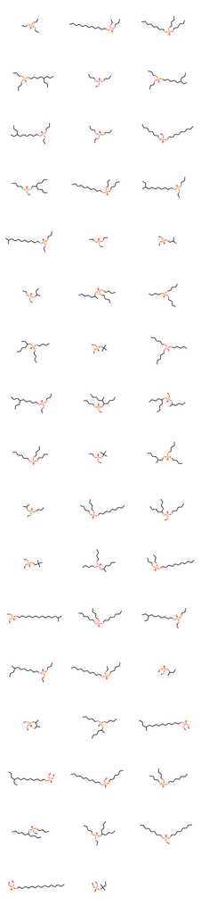

```python
print('Top 20 all biowin added:')
drawsmileslist(top20Bwall)
```

## Further series: OMG run on NMR computer

### Series O

1 additional O, PO5 Alkylextension, saturated **SO_1**

**Some fixing necessary: Create SMILES for Biowin**

The run was terminated after C14, the OMG outputs were stored but not converted into smiles.txt. We also did not get the dictionary returned from OMG

# series 1, alkylextension

# Workflow for alkyl variation

sumS = 'C4H11O5P' #starting sumformula -> #startformula() to promt input fragment = 'organophosphate' #initial fragment input to OMG OMGgoodcmd = "" OMGbadcmd = "" OMGadditional = "" outnameOMG = 'OMG0616_SO_1' #name to store OMG output allsmilesname = 'allsmiles0616_SO_1' #name of file in which all SMILES together are stored ToaddCH2 = True #Boolean to switch on or off timesCH2 = 15 #number of CH2 units to add

# Sumformula -> Elements df

ElementstableS = makeElementsTable(sumS)

# addAtomX(df,X,nx=1, Y='non', ny=1)

# addnAtoms(df,times,X, nx=1, Y='non', ny=1)

if ToaddCH2: ElementstableSadded = addCH2(ElementstableS,timesCH2) print(ElementstableSadded) else: ElementstableSadded = ElementstableS

# Elements df -> list of formulas

formulalistS = makeformulalist(ElementstableSadded)

# List of formulas -> file per formula with structures(sdf)

# -> dictionary of formulas:filename

OMGoutdictS = runOMG(formulalistS, outnameOMG, fragment, OMGgoodcmd, OMGbadcmd, OMGadditional)

# if dictionary of formulas:filename contains errors, delete them

# -> dictionary of formulas:filename without errors

OMGoutdictS = delErrordict(OMGoutdictS)

# dictionary of formulas:filename -> smiles.txt per formula

makeSmilestxtsfromOMGout(OMGoutdictS)

# dictionary of formulas:filename, [smiles.txt per formula] -> one .txt of smiles

OMGoutdicttojoinedtxt(OMGoutdictS, allsmilesname,(Projectdir + '\SMILESmodelin'))

def SDftoSMILESlist(inSDF, infolder): '''coverts SDF to list of kekulized smiles'''

```
#import molecules from SD files
mols = Chem.SDMolSupplier((str(infolder)+"\\"+str(inSDF)))
#create empty list to store smiles in
SMILESlist = []
#iterate trough molecules, convert to smiles and append to list of smiles
for mol in mols:
    Chem.Kekulize(mol)
    out = SMILESlist.append(Chem.MolToSmiles(mol,kekuleSmiles=True))
return(SMILESlist)
```

def writetxt(alist, name, outfolder = os.getcwd()): '''writes a list to a txt with every element in list in next line, input name without ending''' with open(os.path.join(outfolder,(str(name)+'.txt')), 'w') as f: for item in alist: f.write("%s\n" % item)

def jointxts(filenameslist, outname, outfolder=(Projectdir + '\SMILESOMGout'), infolder=(Projectdir + '\SMILESOMGout')): '''joins txts whose names are specified in a list into one txt with specified name. Folder where to find txts and folder where to store joined txt can be specified '''

```
#filenameslist is list of files in infolder, outname is name of outputfile in outfolder
with open(os.path.join(outfolder,(str(outname)+'.txt')), 'w') as outfile:
    for fname in filenameslist:
        with open(os.path.join(infolder, (str(fname)+'.txt'))) as infile:
            for line in infile:
                outfile.write(line)
```

OMG0619dir = "C:\Users\Hannah\Documents\Master UvA\master project\OMG\NMR computer\20200619" fileslist = os.listdir(OMG0619dir)

# move files with 10 and 11 ending to back of list

fileslist.sort(key = 'OMG0616_SO_110.txt'.**eq**) fileslist.sort(key = 'OMG0616_SO_111.txt'.**eq**)

os.chdir(OMG0619dir)

formulas = [] for i in range(12): formula = 'C' + str((4+i)) + 'H' + str((2*(4+i)+3)) + 'PO5' formulas.append(formula)

for i in range(12): smileslist = SDftoSMILESlist(fileslist[i],OMG0619dir) print(smileslist) writetxt(smileslist,formulas[i],OMG0619dir)

# C15 gives error

formulas = [] for i in range(13): formula = 'C' + str((4+i)) + 'H' + str((2*(4+i)+3)) + 'PO5' formulas.append(formula)

smileslist = SDftoSMILESlist(fileslist[11],OMG0619dir) print(smileslist) writetxt(smileslist,formulas[11],OMG0619dir)

# join C4-C14 smiles txts

jointxts(formulas[0:11],'OMG_0616_SO_1allsmiles',OMG0619dir,str(OMG0619dir)+'\smiles')

*Biowin results*  
For C4 to C14 saturated, PO5

```python
#upload Biowin results for series SO_1
OMG0619dir = "C:\\Users\\Hannah\\Documents\\Master UvA\\master project\\OMG\\NMR computer\\20200619"
os.chdir(OMG0619dir)

OMG0616SO_1biowin = pd.read_csv('OMG_0616_SO_1biowin.txt', sep="\t", header=None,
                          names=["Biowin1", "Biowin2","Biowin3", "Biowin4","Biowin5","Biowin6","Biowin7","SMILES"])
```

```
405 ready biodegradable molecules in table, out of  321467 total
Ready biodegradable:
```

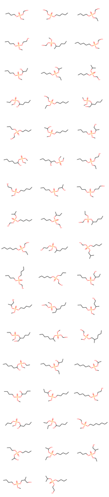

```python
ready_biodegradable_show(OMG0616SO_1biowin)
```

```python
OMG0616SO_1readybiodeg = ready_biodegradable(OMG0616SO_1biowin)
```

```
405 ready biodegradable molecules in table, out of  321467 total
Ready biodegradable:
```

```python
OMG0616SO_1readybiodeg
```

|  | Biowin1 | Biowin2 | Biowin3 | Biowin4 | Biowin5 | Biowin6 | Biowin7 | SMILES |
| --- | --- | --- | --- | --- | --- | --- | --- | --- |
| 27 | 1.2343 | 1.0 | 3.3733 | 4.4257 | 0.6370 | 0.6674 | 1.1229 | CCCCOP(=O)(OC)OCO |
| 130 | 1.2276 | 1.0 | 3.3423 | 4.4055 | 0.6446 | 0.6729 | 1.1489 | CCCCCOP(=O)(OC)OCO |
| 163 | 1.2276 | 1.0 | 3.3423 | 4.4055 | 0.6446 | 0.6729 | 1.1489 | CCCCOP(=O)(OCC)OCO |
| 164 | 1.2276 | 1.0 | 3.3423 | 4.4055 | 0.6446 | 0.6729 | 1.1489 | CCCCOP(=O)(OC)OCCO |
| 225 | 1.2210 | 1.0 | 3.3113 | 4.3852 | 0.5032 | 0.4517 | 0.8775 | CCCCC(C)OP(=O)(OC)OCO |
| ... | ... | ... | ... | ... | ... | ... | ... | ... |
| 317374 | 1.2893 | 1.0 | 3.4237 | 4.5329 | 0.6984 | 0.7095 | 1.0131 | CCCCCCCOP(=O)(OCCO)OCCCCC |
| 317786 | 1.2893 | 1.0 | 3.4237 | 4.5329 | 0.5493 | 0.4884 | 0.7157 | CCCCCOP(=O)(OCC)OCCC(O)CCCC |
| 317794 | 1.2893 | 1.0 | 3.4237 | 4.5329 | 0.5493 | 0.4884 | 0.7157 | CCCCCC(O)CCOP(=O)(OCC)OCCCC |
| 318164 | 1.2893 | 1.0 | 3.4237 | 4.5329 | 0.5493 | 0.4884 | 0.7157 | CCCCOP(=O)(OCC)OCCC(CO)CCCC |
| 318216 | 1.2893 | 1.0 | 3.4237 | 4.5329 | 0.5493 | 0.4884 | 0.7157 | CCCCOP(=O)(OCC)OCCCC(O)CCCC |

405 rows × 8 columns

```python
OMG0616SO_1rbBio3better = biowin_better_than_original(OMG0616SO_1readybiodeg,'Biowin3','tibp',tibpbiowin)
```

```
Better than  tibp  in Biowin3 :
 405
```

```python
OMG0616SO_1rbBio3better = biowin_better_than_original(OMG0616SO_1readybiodeg,'Biowin4','tibp',tibpbiowin)
```

```
Better than  tibp  in Biowin4 :
 405
```

```python
OMG0616SO_1rbBio3better = biowin_better_than_original(OMG0616SO_1readybiodeg,'Biowin1','tibp',tibpbiowin)
```

```
Better than  tibp  in Biowin1 :
 405
```

```python
OMG0616SO_1rbBio7better = biowin_better_than_original(OMG0616SO_1readybiodeg,'Biowin7','tibp',tibpbiowin)
OMG0616SO_1rbBio7better
```

```
Better than  tibp  in Biowin7 :
 394
```

|  | Biowin1 | Biowin2 | Biowin3 | Biowin4 | Biowin5 | Biowin6 | Biowin7 | SMILES |
| --- | --- | --- | --- | --- | --- | --- | --- | --- |
| 27 | 1.2343 | 1.0 | 3.3733 | 4.4257 | 0.6370 | 0.6674 | 1.1229 | CCCCOP(=O)(OC)OCO |
| 130 | 1.2276 | 1.0 | 3.3423 | 4.4055 | 0.6446 | 0.6729 | 1.1489 | CCCCCOP(=O)(OC)OCO |
| 163 | 1.2276 | 1.0 | 3.3423 | 4.4055 | 0.6446 | 0.6729 | 1.1489 | CCCCOP(=O)(OCC)OCO |
| 164 | 1.2276 | 1.0 | 3.3423 | 4.4055 | 0.6446 | 0.6729 | 1.1489 | CCCCOP(=O)(OC)OCCO |
| 225 | 1.2210 | 1.0 | 3.3113 | 4.3852 | 0.5032 | 0.4517 | 0.8775 | CCCCC(C)OP(=O)(OC)OCO |
| ... | ... | ... | ... | ... | ... | ... | ... | ... |
| 317374 | 1.2893 | 1.0 | 3.4237 | 4.5329 | 0.6984 | 0.7095 | 1.0131 | CCCCCCCOP(=O)(OCCO)OCCCCC |
| 317786 | 1.2893 | 1.0 | 3.4237 | 4.5329 | 0.5493 | 0.4884 | 0.7157 | CCCCCOP(=O)(OCC)OCCC(O)CCCC |
| 317794 | 1.2893 | 1.0 | 3.4237 | 4.5329 | 0.5493 | 0.4884 | 0.7157 | CCCCCC(O)CCOP(=O)(OCC)OCCCC |
| 318164 | 1.2893 | 1.0 | 3.4237 | 4.5329 | 0.5493 | 0.4884 | 0.7157 | CCCCOP(=O)(OCC)OCCC(CO)CCCC |
| 318216 | 1.2893 | 1.0 | 3.4237 | 4.5329 | 0.5493 | 0.4884 | 0.7157 | CCCCOP(=O)(OCC)OCCCC(O)CCCC |

394 rows × 8 columns

```python
OMG0616SO_1rbBio6better = biowin_better_than_original(OMG0616SO_1readybiodeg,'Biowin6','tibp',tibpbiowin)
```

```
Better than  tibp  in Biowin6 :
 405
```

```
Molecules classified as biodegradable by Biowin, which perform worse than tibp in BIowin7,
 so for anaerobic conditions.
```

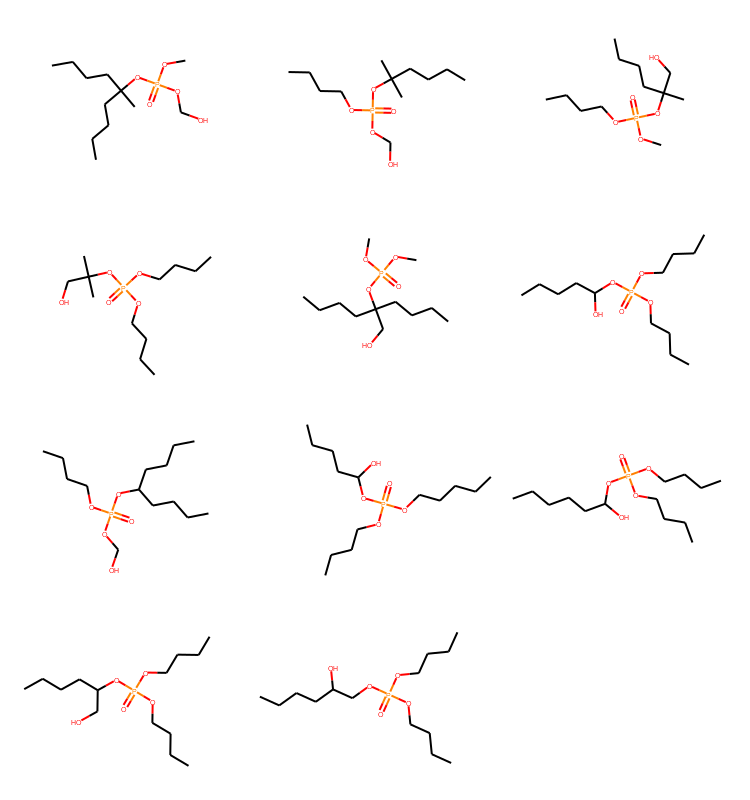

```python
OMG0616SO_1rbBio7worse = OMG0616SO_1readybiodeg[OMG0616SO_1readybiodeg['Biowin7'].astype(float) < float(0.4661)]
len(OMG0616SO_1rbBio7worse.index)
print('Molecules classified as biodegradable by Biowin, which perform worse than tibp in BIowin7, \n so for anaerobic conditions.')
drawsmileslist(OMG0616SO_1rbBio7worse['SMILES'])
```

**SO_2**  
2 additional O, PO6, alkylextension saturated

```python
#load biowin data
OMG_SO2dir = "C:\\Users\\Hannah\\Documents\\Master UvA\\master project\\OMG\\NMR computer\\SO_2"

OMG0623SO_2biowin = pd.read_csv((OMG_SO2dir + '\\0623_SO_2biowin.txt'), sep="\t", header=None,
                          names=["Biowin1", "Biowin2","Biowin3", "Biowin4","Biowin5","Biowin6","Biowin7","SMILES"])
```

```
3650 ready biodegradable molecules in table, out of  380773 total
Ready biodegradable:
```

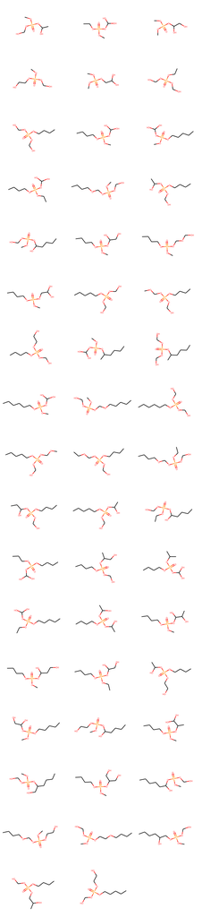

```python
ready_biodegradable_show(OMG0623SO_2biowin)
```

```python
OMG0623SO_2readybiodeg = ready_biodegradable(OMG0623SO_2biowin)
OMG0623SO_2readybiodeg
```

```
3650 ready biodegradable molecules in table, out of  380773 total
Ready biodegradable:
```

|  | Biowin1 | Biowin2 | Biowin3 | Biowin4 | Biowin5 | Biowin6 | Biowin7 | SMILES |
| --- | --- | --- | --- | --- | --- | --- | --- | --- |
| 2 | 1.2903 | 1.0 | 3.2616 | 4.3035 | 0.6350 | 0.6594 | 1.3296 | COP(=O)(OCO)OC(C)O |
| 3 | 1.2903 | 1.0 | 3.2616 | 4.3035 | 0.6350 | 0.6594 | 1.3296 | CCOP(=O)(OC)OC(O)O |
| 4 | 1.2903 | 1.0 | 3.2616 | 4.3035 | 0.6350 | 0.6594 | 1.3296 | COP(=O)(OC)OC(O)CO |
| 7 | 1.2903 | 1.0 | 3.2616 | 4.3035 | 0.7841 | 0.8320 | 1.6270 | COP(=O)(OCO)OCCO |
| 10 | 1.2903 | 1.0 | 3.2616 | 4.3035 | 0.6350 | 0.6594 | 1.3296 | COP(=O)(OC)OCC(O)O |
| ... | ... | ... | ... | ... | ... | ... | ... | ... |
| 380165 | 1.3454 | 1.0 | 3.3119 | 4.4107 | 0.6965 | 0.7020 | 1.2198 | CCCCOP(=O)(OC)OCCCCCC(O)CO |
| 380166 | 1.3454 | 1.0 | 3.3119 | 4.4107 | 0.6965 | 0.7020 | 1.2198 | CCCCOP(=O)(OC)OCCCCC(O)CCO |
| 380172 | 1.3454 | 1.0 | 3.3119 | 4.4107 | 0.6965 | 0.7020 | 1.2198 | CCCCOP(=O)(OC)OCCCCCCC(O)O |
| 380286 | 1.3454 | 1.0 | 3.3119 | 4.4107 | 0.6965 | 0.7020 | 1.2198 | CCCCCCCCOP(=O)(OC)OCCC(O)O |
| 380397 | 1.3454 | 1.0 | 3.3119 | 4.4107 | 0.6965 | 0.7020 | 1.2198 | CCCCC(O)CCCOP(=O)(OC)OCCCO |

3650 rows × 8 columns

```python
OMG0623SO_2rbBio3better = biowin_better_than_original(OMG0623SO_2readybiodeg,'Biowin3','tibp',tibpbiowin)
```

```
Better than  tibp  in Biowin3 :
 3650
```

```python
OMG0623SO_2rbBio1better = biowin_better_than_original(OMG0623SO_2readybiodeg,'Biowin1','tibp',tibpbiowin)
```

```
Better than  tibp  in Biowin1 :
 3635
```

```python
OMG0623SO_2rbBio4better = biowin_better_than_original(OMG0623SO_2readybiodeg,'Biowin4','tibp',tibpbiowin)
```

```
Better than  tibp  in Biowin4 :
 3650
```

```python
OMG0623SO_2rbBio7better = biowin_better_than_original(OMG0623SO_2readybiodeg,'Biowin7','tibp',tibpbiowin)
```

```
Better than  tibp  in Biowin7 :
 3645
```

```
Molecules classified as biodegradable by Biowin, which perform worse than tibp in Biowin7,
 so for anaerobic conditions.
```

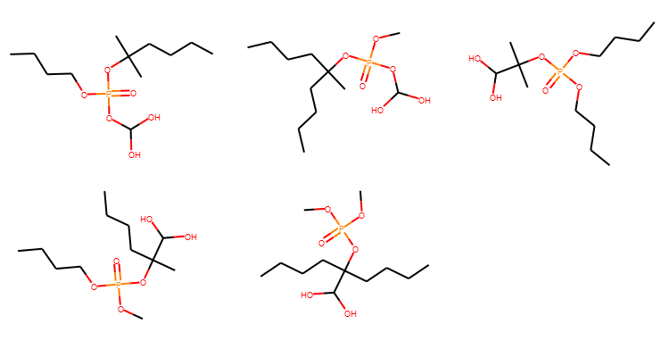

```python
OMG0623SO_2rbBio7worse = OMG0623SO_2readybiodeg[OMG0623SO_2readybiodeg['Biowin7'].astype(float) < float(0.4661)]
len(OMG0623SO_2rbBio7worse.index)
print('Molecules classified as biodegradable by Biowin, which perform worse than tibp in Biowin7, \n so for anaerobic conditions.')
drawsmileslist(OMG0623SO_2rbBio7worse['SMILES'])
```

**SO_3**  
Three additional O, PO7 saturated

```
3312 ready biodegradable molecules in table, out of  233050 total
Ready biodegradable:

3312 ready biodegradable molecules in table, out of  233050 total
Ready biodegradable:
```

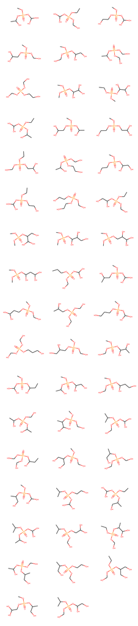

```python
OMG_SO3dir = "C:\\Users\\Hannah\\Documents\\Master UvA\\master project\\OMG\\NMR computer\\SO_3"

OMG0623SO_3biowin = pd.read_csv((OMG_SO3dir + '\\0623_SO_3biowin.txt'), sep="\t", header=None,
                          names=["Biowin1", "Biowin2","Biowin3", "Biowin4","Biowin5","Biowin6","Biowin7","SMILES"])
OMG0623SO_3readybiodeg = ready_biodegradable(OMG0623SO_3biowin)
ready_biodegradable_show(OMG0623SO_3biowin)
```

```python
OMG0623SO_3rbBio7worse = OMG0623SO_3readybiodeg[OMG0623SO_3readybiodeg['Biowin7'].astype(float) < float(0.4661)]
len(OMG0623SO_3rbBio7worse.index)
#print('Molecules classified as biodegradable by Biowin, which perform worse than tibp in Biowin7, \n so for anaerobic conditions.')
#drawsmileslist(OMG0623SO_3rbBio7worse['SMILES'])
```

```
0
```

```python
OMG0623SO_3rbBio1better = biowin_better_than_original(OMG0623SO_3readybiodeg,'Biowin1','tibp',tibpbiowin)
```

```
Better than  tibp  in Biowin1 :
 3312
```

**SO_4**

```
10282 ready biodegradable molecules in table, out of  302438 total
Ready biodegradable:

10282 ready biodegradable molecules in table, out of  302438 total
Ready biodegradable:
```

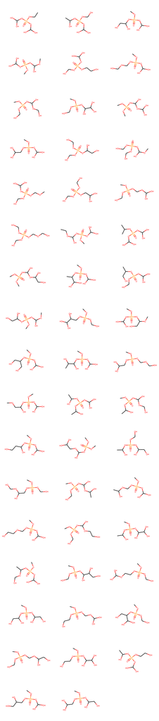

```python
OMG_SO_4dir = "C:\\Users\\Hannah\\Documents\\Master UvA\\master project\\OMG\\NMR computer\\SO_4"

OMG_SO_4biowin = pd.read_csv((OMG_SO_4dir + '\\OMG_SO_4_biowin.txt'), sep="\t", header=None,
                          names=["Biowin1", "Biowin2","Biowin3", "Biowin4","Biowin5","Biowin6","Biowin7","SMILES"])
OMG_SO_4readybiodeg = ready_biodegradable(OMG_SO_4biowin)
ready_biodegradable_show(OMG_SO_4biowin)
```

### Series N

**SN_1H** One N, PO4 saturated

```
14 ready biodegradable molecules in table, out of  16765 total
Ready biodegradable:

14 ready biodegradable molecules in table, out of  16765 total
Ready biodegradable:
```

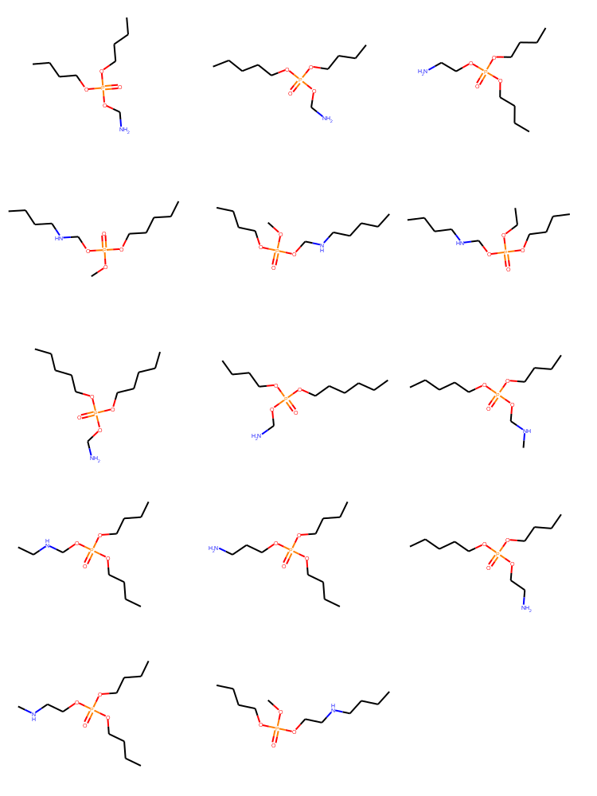

```python
OMG_SN_1Hdir = "C:\\Users\\Hannah\\Documents\\Master UvA\\master project\\OMG\\NMR computer\\SN_1H"

OMG0623SN_1Hbiowin = pd.read_csv((OMG_SN_1Hdir + '\\0623_SN_1Hbiowin.txt'), sep="\t", header=None,
                          names=["Biowin1", "Biowin2","Biowin3", "Biowin4","Biowin5","Biowin6","Biowin7","SMILES"])
OMG0623SN_1Hreadybiodeg = ready_biodegradable(OMG0623SN_1Hbiowin)
ready_biodegradable_show(OMG0623SN_1Hbiowin)
```

**SN_2H**

```python
OMG_SN_2Hdir = "C:\\Users\\Hannah\\Documents\\Master UvA\\master project\\OMG\\NMR computer\\SN_2H"

OMG0623SN_2Hbiowin = pd.read_csv((OMG_SN_2Hdir + '\\0623_SN_2Hbiowin.txt'), sep="\t", header=None,
                          names=["Biowin1", "Biowin2","Biowin3", "Biowin4","Biowin5","Biowin6","Biowin7","SMILES"])
OMG0623SN_2Hreadybiodeg = ready_biodegradable(OMG0623SN_2Hbiowin)
ready_biodegradable_show(OMG0623SN_2Hbiowin)
len(OMG0623SN_2Hbiowin.index)
```

```
DataFrame is empty, no ready biodegradable molecules
DataFrame is empty, no ready biodegradable molecules
```

```
16111
```

**SN_3H**

```python
OMG_SN_3Hdir = "C:\\Users\\Hannah\\Documents\\Master UvA\\master project\\OMG\\NMR computer\\SN_3H"

OMG_SN_3Hbiowin = pd.read_csv((OMG_SN_3Hdir + '\\OMG_SN_3H_biowin.txt'), sep="\t", header=None,
                          names=["Biowin1", "Biowin2","Biowin3", "Biowin4","Biowin5","Biowin6","Biowin7","SMILES"])
OMG_SN_3Hreadybiodeg = ready_biodegradable(OMG_SN_3Hbiowin)
ready_biodegradable_show(OMG_SN_3Hbiowin)
len(OMG_SN_3Hbiowin.index)
```

```
DataFrame is empty, no ready biodegradable molecules
DataFrame is empty, no ready biodegradable molecules
```

```
103953
```

### Series S

**SS_1**

```python
OMG_SS_1dir = "C:\\Users\\Hannah\\Documents\\Master UvA\\master project\\OMG\\NMR computer\\SS_1"

nosquaretxtS(str(OMG_SS_1dir+'\\allsmiles0623_SS_1_.txt'), 'nosallsmiles_SS_1_' ,OMG_SS_1dir)
```

```
[SH] replaced with S in  nosallsmiles_SS_1_ .txt in  C:\Users\Hannah\Documents\Master UvA\master project\OMG\NMR computer\SS_1
```

```python
OMG_SS_1_biowin = pd.read_csv((OMG_SS_1dir + '\\OMG_SS_1_biowin.txt'), sep="\t", header=None,
                          names=["Biowin1", "Biowin2","Biowin3", "Biowin4","Biowin5","Biowin6","Biowin7","SMILES"])
OMG_SS_1readybiodeg = ready_biodegradable(OMG_SS_1_biowin)
len(OMG_SS_1_biowin.index)
```

```
DataFrame is empty, no ready biodegradable molecules
```

```
43277
```

**SS_2**

```python
OMG_SS_2dir = "C:\\Users\\Hannah\\Documents\\Master UvA\\master project\\OMG\\NMR computer\\SS_2"

nosquaretxtS(str(OMG_SS_2dir+'\\allsmiles0623_SS_2_.txt'), 'nosallsmiles_SS_2_' ,OMG_SS_2dir)
```

```
[SH] replaced with S in  nosallsmiles_SS_2_ .txt in  C:\Users\Hannah\Documents\Master UvA\master project\OMG\NMR computer\SS_2
```

```python
OMG_SS_2_biowin = pd.read_csv((OMG_SS_2dir + '\\OMG_SS_2_biowin.txt'), sep="\t", header=None,
                          names=["Biowin1", "Biowin2","Biowin3", "Biowin4","Biowin5","Biowin6","Biowin7","SMILES"])
OMG_SS_2readybiodeg = ready_biodegradable(OMG_SS_2_biowin)
len(OMG_SS_2_biowin.index)
```

```
DataFrame is empty, no ready biodegradable molecules
```

```
486215
```

**SS_3**

```python
OMG_SS_3dir = "C:\\Users\\Hannah\\Documents\\Master UvA\\master project\\OMG\\NMR computer\\SS_3"

nosquaretxtS(str(OMG_SS_3dir+'\\allsmiles0623_SS_3_a.txt'), 'nosallsmiles_SS_3_' ,OMG_SS_3dir)
```

```
[SH] replaced with S in  nosallsmiles_SS_3_ .txt in  C:\Users\Hannah\Documents\Master UvA\master project\OMG\NMR computer\SS_3
```

```python
OMG_SS_3_biowin = pd.read_csv((OMG_SS_3dir + '\\OMG_SS_3_biowin.txt'), sep="\t", header=None,
                          names=["Biowin1", "Biowin2","Biowin3", "Biowin4","Biowin5","Biowin6","Biowin7","SMILES"])
OMG_SS_3readybiodeg = ready_biodegradable(OMG_SS_3_biowin)
len(OMG_SS_3_biowin.index)
```

```
DataFrame is empty, no ready biodegradable molecules
```

```
407830
```

### Double bonds - DB series

Series with reduced amount of H in the starting fragment, so molecules containing rings and/or double bonds were combined to be analyzed faster

```python
#make one txt with all DB series
OMG_DB_allsmilesdir = "C:\\Users\\Hannah\\Documents\\Master UvA\\master project\\OMG\\NMR computer\\DB\\allsmiles"
OMG_allDBlist = os.listdir(OMG_DB_allsmilesdir)
#No additional heteroatoms DB series
OMG_SDBlist = ['allsmilesOMG_S1DB_1.txt','allsmilesOMG_S2DB_1.txt','allsmilesOMG_S3DB_1.txt']
#Additional N containing DB series
OMG_SN_DBlist = ['allsmilesOMG_SN_1_1DB.txt',
 'allsmilesOMG_SN_1_2DB.txt',
 'allsmilesOMG_SN_1_3DB_a.txt']
#Additional O conataining DB series
OMG_SOs_DBlist = ['allsmilesOMG_SO_1_1DB.txt',
 'allsmilesOMG_SO_1_2DB.txt',
 'allsmilesOMG_SO_1_3DB.txt',
 'allsmilesOMG_SO_2_1DB.txt',
 'allsmilesOMG_SO_2_2DB.txt',
 'allsmilesOMG_SO_2_3DB.txt',
 'allsmilesOMG_SO_3_1DB.txt',
 'allsmilesOMG_SO_3_2DB.txt',
 'allsmilesOMG_SO_3_3DB.txt']
#Additional S containing DB series
OMG_SS_DBlist =  ['allsmilesOMG_SS_1_1DB.txt',
 'allsmilesOMG_SS_1_2DB.txt',
 'allsmilesOMG_SS_1_3DB.txt']

#jointxts(OMG_SDBlist,'OMG_SCDB_SMILES',OMG_DB_allsmilesdir,OMG_DB_allsmilesdir)
#jointxts(OMG_SN_DBlist,'OMG_SN_DB_SMILES',OMG_DB_allsmilesdir,OMG_DB_allsmilesdir)
#jointxts(OMG_SOs_DBlist,'OMG_SOs_DB_SMILES',OMG_DB_allsmilesdir,OMG_DB_allsmilesdir)
#jointxts(OMG_SS_DBlist,'OMG_SS_DB_SMILES',OMG_DB_allsmilesdir,OMG_DB_allsmilesdir)
```

```python
#nosquaretxtS(str(OMG_DB_allsmilesdir+'\\OMG_SS_DB_SMILES.txt'), 'OMG_SS_DB_SMILES' ,OMG_DB_allsmilesdir)
```

```
6 ready biodegradable molecules in table, out of  1328649 total
Ready biodegradable:

6 ready biodegradable molecules in table, out of  1328649 total
Ready biodegradable:
```

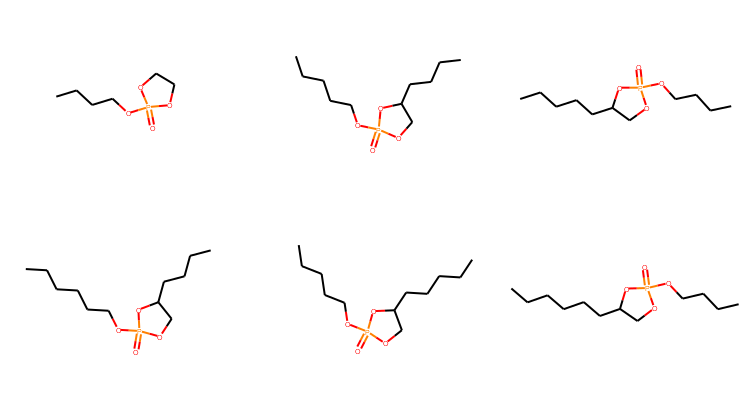

```python
#SDB=SCDB: no additional heteroatoms DB series or carbon DB series
OMG_SCDB_biowin = pd.read_csv((OMG_DB_allsmilesdir+'\\OMG_SCDB_biowin.txt'), sep="\t", header=None,
                          names=["Biowin1", "Biowin2","Biowin3", "Biowin4","Biowin5","Biowin6","Biowin7","SMILES"])
OMG_SCDB_readybiodeg = ready_biodegradable(OMG_SCDB_biowin)
ready_biodegradable_show(OMG_SCDB_biowin)
```

```
1 ready biodegradable molecules in table, out of  576934 total
Ready biodegradable:

1 ready biodegradable molecules in table, out of  576934 total
Ready biodegradable:
```

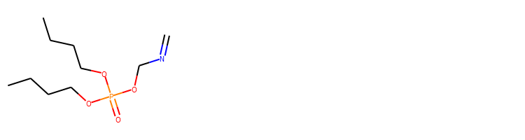

```python
#SN_DB: N containing DB series
OMG_SN_DB_biowin = pd.read_csv((OMG_DB_allsmilesdir+'\\OMG_SN_DB_biowin.txt'), sep="\t", header=None,
                          names=["Biowin1", "Biowin2","Biowin3", "Biowin4","Biowin5","Biowin6","Biowin7","SMILES"])
OMG_SN_DB_readybiodeg = ready_biodegradable(OMG_SN_DB_biowin)
ready_biodegradable_show(OMG_SN_DB_biowin)
```

```python
#SS_DB: S containing DB series
OMG_SS_DB_biowin = pd.read_csv((OMG_DB_allsmilesdir+'\\OMG_SS_DB_biowin_1.txt'), sep="\t", header=None,
                          names=["Biowin1", "Biowin2","Biowin3", "Biowin4","Biowin5","Biowin6","Biowin7","SMILES"])
OMG_SS_DB_readybiodeg = ready_biodegradable(OMG_SS_DB_biowin)
ready_biodegradable_show(OMG_SS_DB_biowin)
len(OMG_SS_DB_biowin.index)
```

```
DataFrame is empty, no ready biodegradable molecules
DataFrame is empty, no ready biodegradable molecules
```

```
933685
```

```
38573 ready biodegradable molecules in table, out of  3088185 total
Ready biodegradable:

38573 ready biodegradable molecules in table, out of  3088185 total
Ready biodegradable:
```

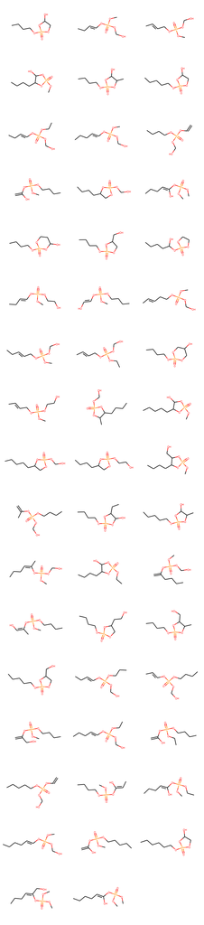

```python
#SOs_DB: O containing DB series
OMG_SOs_DB_biowin = pd.read_csv((OMG_DB_allsmilesdir+'\\OMG_SOs_DB_biowin.txt'), sep="\t", header=None,
                          names=["Biowin1", "Biowin2","Biowin3", "Biowin4","Biowin5","Biowin6","Biowin7","SMILES"])
OMG_SOs_DB_readybiodeg = ready_biodegradable(OMG_SOs_DB_biowin)
ready_biodegradable_show(OMG_SOs_DB_biowin)
```

```python
OMG_SOs_DB_readybiodeg
```

|  | Biowin1 | Biowin2 | Biowin3 | Biowin4 | Biowin5 | Biowin6 | Biowin7 | SMILES |
| --- | --- | --- | --- | --- | --- | --- | --- | --- |
| 205 | 1.2353 | 1.0 | 3.3778 | 4.4286 | 0.6253 | 0.6018 | 1.0960 | CCCCOP1(=O)OCC(O)O1 |
| 213 | 1.2353 | 1.0 | 3.3778 | 4.4286 | 0.5565 | 0.4882 | 0.9239 | CC/C=C/OP(=O)(OC)OCO |
| 483 | 1.2353 | 1.0 | 3.3778 | 4.4286 | 0.5565 | 0.4882 | 0.9239 | C/C=C/COP(=O)(OC)OCO |
| 590 | 1.2286 | 1.0 | 3.3468 | 4.4084 | 0.5767 | 0.4162 | 1.1759 | CCCCC1OP(=O)(OC)OC1O |
| 621 | 1.2286 | 1.0 | 3.3468 | 4.4084 | 0.5767 | 0.4162 | 1.1759 | CCCCOP1(=O)OC(C)C(O)O1 |
| ... | ... | ... | ... | ... | ... | ... | ... | ... |
| 3087659 | 1.4310 | 1.0 | 3.3376 | 4.3781 | 0.6582 | 0.4650 | 1.5949 | CC(O)OP1(=O)OC(O)C#CC(O)O1 |
| 3087660 | 1.4310 | 1.0 | 3.3376 | 4.3781 | 0.7468 | 0.5189 | 1.6862 | O=P12OC(O)C=C(CC(O)O1)C(O)O2 |
| 3087670 | 1.4310 | 1.0 | 3.3376 | 4.3781 | 0.7582 | 0.3594 | 1.9981 | O=P12OC(O)C3C(C(O)O1)C3C(O)O2 |
| 3087863 | 1.1862 | 1.0 | 3.3822 | 4.5048 | 0.6375 | 0.5637 | 1.3951 | O=C(O)COP1(=O)OCC(=CO)CO1 |
| 3088107 | 1.1862 | 1.0 | 3.3822 | 4.5048 | 0.6375 | 0.5637 | 1.3951 | O=C(O)COP1(=O)OCC=C(O)CO1 |

38573 rows × 8 columns

## Collection of ALL READY BIODEGRADABLE molecules generated with OMG

All molecules from the datasets loaded and analyzed above, which qualified as ready biodegradable according to the Biowin prediction were collected in one dataframe, to predict properties with QSAR models.

Biodegradability is the main property we want to optimize for, therefore a hard cut-off is applied. This steps reduces the amount of molecules greatly, so that the new, ready biodegradable dataset is more workable.

First, one dataframe was created for all saturated series (all_OMG_ready), and one dataframe for all DB/ring containing series (DBall_OMG_ready). With the SMILES codes of these datasets, more properties were predicted with QSAR models. These are subsequently uploaded here, before everything is combined into one DataFrame.

Throughout, the model results are compared to model resutls for tibp.

```python
#saturated series
ready_C17 = ready_biodegradable(S1C17biowin)
ready_N1 = ready_biodegradable(OMG0623SN_1Hbiowin)
ready_O1 = ready_biodegradable(OMG0616SO_1biowin)
ready_O2 = ready_biodegradable(OMG0623SO_2biowin)
ready_O3 = ready_biodegradable(OMG0623SO_3biowin)
ready_O4 = ready_biodegradable(OMG_SO_4biowin)

all_OMG_ready = pd.concat([ready_C17, ready_N1, ready_O1, ready_O2, ready_O3])
len(all_OMG_ready.index)
```

```
52 ready biodegradable molecules in table, out of  296223 total
Ready biodegradable:

14 ready biodegradable molecules in table, out of  16765 total
Ready biodegradable:

405 ready biodegradable molecules in table, out of  321467 total
Ready biodegradable:

3650 ready biodegradable molecules in table, out of  380773 total
Ready biodegradable:

3312 ready biodegradable molecules in table, out of  233050 total
Ready biodegradable:

10282 ready biodegradable molecules in table, out of  302438 total
Ready biodegradable:
```

```
7433
```

```python
#series with double bonds
DBreadydfs = [OMG_SCDB_readybiodeg,OMG_SN_DB_readybiodeg, OMG_SOs_DB_readybiodeg]
for df in DBreadydfs:
    print(len(df.index))

DBall_OMG_ready = pd.concat(DBreadydfs)
len(DBall_OMG_ready.index)
```

```
6
1
38573
```

```
38580
```

```python
#writetxt(list(all_OMG_ready['SMILES']), 'all_OMG_readybiodeg_SMILES_inclSO4', (Projectdir + '\\OMG readys'))
#writetxt(list(DBall_OMG_ready['SMILES']), 'DBall_OMG_readybiodeg_SMILES', (Projectdir + '\\OMG readys\\DB'))
```

### Biowin

```python
all_OMG_ready_biowin = pd.read_csv((Projectdir + '\\OMG readys\\all_OMG_readybiodeg_biowin.txt'), sep="\t", header=None,
                          names=["Biowin1", "Biowin2","Biowin3", "Biowin4","Biowin5","Biowin6","Biowin7","SMILES"])
lower_than_original(all_OMG_ready_biowin, 'Biowin7','tibp',tibpbiowin)
```

```
Lower value than  tibp  in Biowin7 :
 20
```

|  | Biowin1 | Biowin2 | Biowin3 | Biowin4 | Biowin5 | Biowin6 | Biowin7 | SMILES |
| --- | --- | --- | --- | --- | --- | --- | --- | --- |
| 10 | 1.2600 | 1.0 | 3.6594 | 4.7361 | 0.5205 | 0.4729 | 0.4051 | CCCCOP(=O)(OCCCC)OCCCC |
| 17 | 1.2533 | 1.0 | 3.6284 | 4.7158 | 0.5282 | 0.4790 | 0.4311 | CCCCCOP(=O)(OCCCC)OCCCC |
| 23 | 1.2466 | 1.0 | 3.5974 | 4.6956 | 0.5359 | 0.4852 | 0.4571 | CCCCCOP(=O)(OCCCC)OCCCCC |
| 24 | 1.2466 | 1.0 | 3.5974 | 4.6956 | 0.5359 | 0.4852 | 0.4571 | CCCCCCOP(=O)(OCCCC)OCCCC |
| 151 | 1.1187 | 1.0 | 3.2735 | 4.4199 | 0.6033 | 0.4983 | 0.3898 | CCCCC(C)(CCCC)OP(=O)(OC)OCO |
| 152 | 1.1187 | 1.0 | 3.2735 | 4.4199 | 0.6033 | 0.4983 | 0.3898 | CCCCOP(=O)(OCO)OC(C)(C)CCCC |
| 165 | 1.1187 | 1.0 | 3.2735 | 4.4199 | 0.6033 | 0.4983 | 0.3898 | CCCCOP(=O)(OC)OC(C)(CO)CCCC |
| 171 | 1.1187 | 1.0 | 3.2735 | 4.4199 | 0.6033 | 0.4983 | 0.3898 | CCCCOP(=O)(OCCCC)OC(C)(C)CO |
| 178 | 1.1187 | 1.0 | 3.2735 | 4.4199 | 0.6033 | 0.4983 | 0.3898 | CCCCC(CO)(CCCC)OP(=O)(OC)OC |
| 213 | 1.4044 | 1.0 | 3.7530 | 4.8222 | 0.5417 | 0.4823 | 0.3720 | CCCCOP(=O)(OCCCC)OC(O)CCCC |
| 292 | 1.3977 | 1.0 | 3.7220 | 4.8020 | 0.5493 | 0.4884 | 0.3980 | CCCCOP(=O)(OCO)OC(CCCC)CCCC |
| 325 | 1.3977 | 1.0 | 3.7220 | 4.8020 | 0.5493 | 0.4884 | 0.3980 | CCCCCOP(=O)(OCCCC)OC(O)CCCC |
| 326 | 1.3977 | 1.0 | 3.7220 | 4.8020 | 0.5493 | 0.4884 | 0.3980 | CCCCCC(O)OP(=O)(OCCCC)OCCCC |
| 347 | 1.3977 | 1.0 | 3.7220 | 4.8020 | 0.5493 | 0.4884 | 0.3980 | CCCCOP(=O)(OCCCC)OC(CO)CCCC |
| 435 | 1.3977 | 1.0 | 3.7220 | 4.8020 | 0.5493 | 0.4884 | 0.3980 | CCCCOP(=O)(OCCCC)OCC(O)CCCC |
| 1948 | 1.2699 | 1.0 | 3.3982 | 4.5263 | 0.6167 | 0.5016 | 0.3307 | CCCCOP(=O)(OC(O)O)OC(C)(C)CCCC |
| 1949 | 1.2699 | 1.0 | 3.3982 | 4.5263 | 0.6167 | 0.5016 | 0.3307 | CCCCC(C)(CCCC)OP(=O)(OC)OC(O)O |
| 2073 | 1.2699 | 1.0 | 3.3982 | 4.5263 | 0.6167 | 0.5016 | 0.3307 | CCCCOP(=O)(OCCCC)OC(C)(C)C(O)O |
| 2136 | 1.2699 | 1.0 | 3.3982 | 4.5263 | 0.6167 | 0.5016 | 0.3307 | CCCCOP(=O)(OC)OC(C)(CCCC)C(O)O |
| 2446 | 1.2699 | 1.0 | 3.3982 | 4.5263 | 0.6167 | 0.5016 | 0.3307 | CCCCC(CCCC)(OP(=O)(OC)OC)C(O)O |

```python
DBall_OMG_ready_biowin = pd.read_csv((Projectdir + '\\OMG readys\\DB\\DBall_OMG_ready_biowin.txt'), sep="\t", header=None,
                          names=["Biowin1", "Biowin2","Biowin3", "Biowin4","Biowin5","Biowin6","Biowin7","SMILES"])
lower_than_original(DBall_OMG_ready_biowin, 'Biowin7','tibp',tibpbiowin)
```

```
Lower value than  tibp  in Biowin7 :
 6
```

|  | Biowin1 | Biowin2 | Biowin3 | Biowin4 | Biowin5 | Biowin6 | Biowin7 | SMILES |
| --- | --- | --- | --- | --- | --- | --- | --- | --- |
| 5617 | 1.2211 | 1.0 | 3.2579 | 4.3428 | 0.5300 | 0.4518 | 0.4596 | CCCCOP(=O)(OC)OC(O)C(C)=O |
| 5675 | 1.2211 | 1.0 | 3.2579 | 4.3428 | 0.5300 | 0.4518 | 0.4596 | CCCCC(=O)C(O)OP(=O)(OC)OC |
| 7258 | 1.2221 | 1.0 | 3.2624 | 4.3458 | 0.5746 | 0.5742 | 0.3788 | CCCCC(=O)C(O)OP1(=O)OCCO1 |
| 7360 | 1.2221 | 1.0 | 3.2624 | 4.3458 | 0.5746 | 0.5742 | 0.3788 | CCCCC(O)OP1(=O)OCC(=O)CO1 |
| 9219 | 0.5186 | 1.0 | 3.2587 | 4.3427 | 0.5110 | 0.2904 | 0.4614 | CCCCOP1(=O)OCOCOC(O)O1 |
| 11144 | 0.5186 | 1.0 | 3.2587 | 4.3427 | 0.5110 | 0.2904 | 0.4614 | CCCCOP1(=O)OCOC(O)OCO1 |

### mp bp vp

Melting point, boiling point, vapor pressure. Estimated with US EPA EpiSuite

```python
tibp_bpmpvp = pd.read_csv((Projectdir + '\\tibp\\tibp_bpmpvp_wexp.txt'), sep="\t", header=None,
                          names=["bp degC", "mp degC","vp mmHg", "bp degC exp", "mp degC exp","vp mmHg exp",'empty',"SMILES"])
tibp_bpmpvp
```

|  | bp degC | mp degC | vp mmHg | bp degC exp | mp degC exp | vp mmHg exp | empty | SMILES |
| --- | --- | --- | --- | --- | --- | --- | --- | --- |
| 0 | 302.2 | 16.43 | 0.0128 | 264.0 | NaN | NaN | NaN | CC(C)COP(=O)(OCC(C)C)OCC(C)C |

```python
all_OMG_ready_bpmpvp = pd.read_csv((Projectdir + '\\OMG readys\\all_OMG_readybiodeg_bpmpvp.txt'), sep="\t", header=None,
                          names=["bp degC", "mp degC","vp mmHg", "SMILES"])
higher_than_original(all_OMG_ready_bpmpvp, 'mp degC','tibp',tibp_bpmpvp)
```

```
Higher value than  tibp  in mp degC :
 7433
```

|  | bp degC | mp degC | vp mmHg | SMILES |
| --- | --- | --- | --- | --- |
| 0 | 299.40 | 37.50 | 1.550000e-03 | CCCCOP(=O)(OCC)OCCCC |
| 1 | 299.40 | 37.50 | 1.550000e-03 | CCCCCOP(=O)(OC)OCCCC |
| 2 | 313.67 | 55.19 | 4.950000e-04 | CCCCCOP(=O)(OC)OCCCCC |
| 3 | 313.67 | 55.19 | 4.950000e-04 | CCCCCCOP(=O)(OC)OCCCC |
| 4 | 313.67 | 55.19 | 4.950000e-04 | CCCCOP(=O)(OCCC)OCCCC |
| ... | ... | ... | ... | ... |
| 7428 | 402.97 | 86.66 | 6.770000e-09 | CCCCC(O)C(O)C(O)COP(=O)(OC)OC |
| 7429 | 396.81 | 85.76 | 2.550000e-08 | CCCCC(C)COCOP(=O)(OCO)OCO |
| 7430 | 396.81 | 85.76 | 2.550000e-08 | CCCCC(CC)OCOP(=O)(OCO)OCO |
| 7431 | 396.81 | 85.76 | 2.550000e-08 | CCCCCC(C)OCOP(=O)(OCO)OCO |
| 7432 | 403.81 | 86.78 | 1.520000e-08 | CCCCCCCOCOP(=O)(OCO)OCO |

7433 rows × 4 columns

```python
DBall_OMG_ready_bpmpvp = pd.read_csv((Projectdir + '\\OMG readys\\DB\\DBall_OMG_readybiodeg_mpbpvp.txt'), sep="\t", header=None,
                          names=["bp degC", "mp degC","vp mmHg", "SMILES"])
higher_than_original(DBall_OMG_ready_bpmpvp, 'mp degC','tibp',tibp_bpmpvp)
```

```
Higher value than  tibp  in mp degC :
 38580
```

|  | bp degC | mp degC | vp mmHg | SMILES |
| --- | --- | --- | --- | --- |
| 0 | 251.41 | 22.51 | 2.530000e-02 | CCCCOP1(=O)OCCO1 |
| 1 | 323.44 | 69.59 | 2.120000e-04 | CCCCCOP1(=O)OCC(CCCC)O1 |
| 2 | 323.44 | 69.59 | 2.120000e-04 | CCCCCC1COP(=O)(OCCCC)O1 |
| 3 | 336.15 | 78.81 | 8.630000e-05 | CCCCCCOP1(=O)OCC(CCCC)O1 |
| 4 | 336.15 | 78.81 | 8.630000e-05 | CCCCCOP1(=O)OCC(CCCCC)O1 |
| ... | ... | ... | ... | ... |
| 38575 | 383.99 | 83.89 | 2.870000e-08 | CC(O)OP1(=O)OC(O)C#CC(O)O1 |
| 38576 | 389.89 | 84.75 | 1.830000e-08 | O=P12OC(O)C=C(CC(O)O1)C(O)O2 |
| 38577 | 381.42 | 83.51 | 3.480000e-08 | O=P12OC(O)C3C(C(O)O1)C3C(O)O2 |
| 38578 | 395.63 | 85.59 | 6.530000e-08 | O=C(O)COP1(=O)OCC(=CO)CO1 |
| 38579 | 395.67 | 85.59 | 6.510000e-08 | O=C(O)COP1(=O)OCC=C(O)CO1 |

38580 rows × 4 columns

### log Kow, aq. solubility

estimated with models wskow and waternt, both estimate at 25°C

log Kow > 4.5 pose higher concern due to the threat of bioaccumulation. https://www.chemsafetypro.com/Topics/CRA/n_Octanol_Water_Partition_Coefficient_Kow.html

```python
tibp_wskow = pd.read_csv((Projectdir + '\\tibp\\tibp_wskow.txt'), sep="\t", header=None,
                          names=["WSol mg/L", "log WSol mol/L","log Kow", "SMILES"])
tibp_wskow
```

|  | WSol mg/L | log WSol mol/L | log Kow | SMILES |
| --- | --- | --- | --- | --- |
| 0 | 16.22 | -4.215 | 3.6 | CC(C)COP(=O)(OCC(C)C)OCC(C)C |

```python
tibp_waternt = pd.read_csv((Projectdir + '\\tibp\\tibp_waternt.txt'), sep="\t", header=None,
                          names=["log WatSol mol/L", "WatSol mg/L", "SMILES"])
tibp_waternt
```

|  | log WatSol mol/L | WatSol mg/L | SMILES |
| --- | --- | --- | --- |
| 0 | -2.7482 | 475.57 | CC(C)COP(=O)(OCC(C)C)OCC(C)C |

```python
all_OMG_ready_wskow = pd.read_csv((Projectdir + '\\OMG readys\\all_OMG_readybiodeg_wskow.txt'), sep="\t", header=None,
                          names=["WSol mg/L", "log WSol mol/L","log Kow", "SMILES"])
print('Total number of ready biodegradable molecules considered:', len(all_OMG_ready_wskow.index))
higher_than_original(all_OMG_ready_wskow, 'log Kow','tibp',tibp_wskow)
```

```
Total number of ready biodegradable molecules considered: 7433
Higher value than  tibp  in log Kow :
 46
```

|  | WSol mg/L | log WSol mol/L | log Kow | SMILES |
| --- | --- | --- | --- | --- |
| 6 | 10.51000 | -4.404 | 3.82 | CCCCCCOP(=O)(OC)OCCCCC |
| 7 | 10.51000 | -4.404 | 3.82 | CCCCCCCOP(=O)(OC)OCCCC |
| 8 | 10.51000 | -4.404 | 3.82 | CCCCCOP(=O)(OCC)OCCCCC |
| 9 | 10.51000 | -4.404 | 3.82 | CCCCCCOP(=O)(OCC)OCCCC |
| 10 | 7.35500 | -4.559 | 4.00 | CCCCOP(=O)(OCCCC)OCCCC |
| 11 | 7.35500 | -4.559 | 4.00 | CCCCCOP(=O)(OCCC)OCCCC |
| 12 | 3.33100 | -4.925 | 4.31 | CCCCCCOP(=O)(OC)OCCCCCC |
| 13 | 3.33100 | -4.925 | 4.31 | CCCCCCCOP(=O)(OC)OCCCCC |
| 14 | 3.33100 | -4.925 | 4.31 | CCCCCCCCOP(=O)(OC)OCCCC |
| 15 | 3.33100 | -4.925 | 4.31 | CCCCCCOP(=O)(OCC)OCCCCC |
| 16 | 3.33100 | -4.925 | 4.31 | CCCCCCCOP(=O)(OCC)OCCCC |
| 17 | 3.33100 | -4.925 | 4.31 | CCCCCOP(=O)(OCCCC)OCCCC |
| 18 | 3.33100 | -4.925 | 4.31 | CCCCCOP(=O)(OCCC)OCCCCC |
| 19 | 3.33100 | -4.925 | 4.31 | CCCCCCOP(=O)(OCCC)OCCCC |
| 20 | 1.05300 | -5.447 | 4.80 | CCCCCCCCCOP(=O)(OC)OCCCC |
| 21 | 1.05300 | -5.447 | 4.80 | CCCCCCCOP(=O)(OC)OCCCCCC |
| 22 | 1.05300 | -5.447 | 4.80 | CCCCCCCCOP(=O)(OC)OCCCCC |
| 23 | 1.05300 | -5.447 | 4.80 | CCCCCOP(=O)(OCCCC)OCCCCC |
| 24 | 1.05300 | -5.447 | 4.80 | CCCCCCOP(=O)(OCCCC)OCCCC |
| 25 | 1.05300 | -5.447 | 4.80 | CCCCCCOP(=O)(OCCC)OCCCCC |
| 26 | 1.05300 | -5.447 | 4.80 | CCCCCCCOP(=O)(OCCC)OCCCC |
| 27 | 1.05300 | -5.447 | 4.80 | CCCCCCCOP(=O)(OCC)OCCCCC |
| 28 | 1.05300 | -5.447 | 4.80 | CCCCCCCCOP(=O)(OCC)OCCCC |
| 29 | 1.05300 | -5.447 | 4.80 | CCCCCCOP(=O)(OCC)OCCCCCC |
| 30 | 0.33180 | -5.968 | 5.29 | CCCCCCCCCCOP(=O)(OC)OCCCC |
| 31 | 0.33180 | -5.968 | 5.29 | CCCCCCCCCOP(=O)(OC)OCCCCC |
| 32 | 0.33180 | -5.968 | 5.29 | CCCCCCCOP(=O)(OC)OCCCCCCC |
| 33 | 0.33180 | -5.968 | 5.29 | CCCCCCCCOP(=O)(OC)OCCCCCC |
| 34 | 0.33180 | -5.968 | 5.29 | CCCCCCCOP(=O)(OCC)OCCCCCC |
| 35 | 0.33180 | -5.968 | 5.29 | CCCCCCCCOP(=O)(OCC)OCCCCC |
| 36 | 0.33180 | -5.968 | 5.29 | CCCCCCCCCOP(=O)(OCC)OCCCC |
| 37 | 0.33180 | -5.968 | 5.29 | CCCCCCOP(=O)(OCCCC)OCCCCC |
| 38 | 0.33180 | -5.968 | 5.29 | CCCCCOP(=O)(OCCCCC)OCCCCC |
| 39 | 0.33180 | -5.968 | 5.29 | CCCCCCCOP(=O)(OCCCC)OCCCC |
| 40 | 0.33180 | -5.968 | 5.29 | CCCCCCCOP(=O)(OCCC)OCCCCC |
| 41 | 0.33180 | -5.968 | 5.29 | CCCCCCCCOP(=O)(OCCC)OCCCC |
| 42 | 0.33180 | -5.968 | 5.29 | CCCCCCOP(=O)(OCCC)OCCCCCC |
| 43 | 0.10440 | -6.490 | 5.78 | CCCCCCOP(=O)(OCCCCC)OCCCCC |
| 44 | 0.10440 | -6.490 | 5.78 | CCCCCCOP(=O)(OCCCC)OCCCCCC |
| 45 | 0.10440 | -6.490 | 5.78 | CCCCCCCOP(=O)(OCCCC)OCCCCC |
| 46 | 0.10440 | -6.490 | 5.78 | CCCCCCCCOP(=O)(OCCCC)OCCCC |
| 47 | 0.03279 | -7.011 | 6.27 | CCCCCCOP(=O)(OCCCCC)OCCCCCC |
| 48 | 0.03279 | -7.011 | 6.27 | CCCCCCCOP(=O)(OCCCCC)OCCCCC |
| 49 | 0.03279 | -7.011 | 6.27 | CCCCCCCOP(=O)(OCCCC)OCCCCCC |
| 50 | 0.03279 | -7.011 | 6.27 | CCCCCCCCOP(=O)(OCCCC)OCCCCC |
| 51 | 0.03279 | -7.011 | 6.27 | CCCCCCCCCOP(=O)(OCCCC)OCCCC |

```python
all_OMG_ready_waternt = pd.read_csv((Projectdir + '\\OMG readys\\all_OMG_readybiodeg_waternt.txt'), sep="\t", header=None,
                          names=["log WatSol mol/L", "WatSol mg/L", "SMILES"])
print('Total number of ready biodegradable molecules considered:', len(all_OMG_ready_waternt.index))
higher_than_original(all_OMG_ready_waternt, 'WatSol mg/L','tibp',tibp_waternt)
```

```
Total number of ready biodegradable molecules considered: 7433
Higher value than  tibp  in WatSol mg/L :
 7202
```

|  | log WatSol mol/L | WatSol mg/L | SMILES |
| --- | --- | --- | --- |
| 0 | -2.3469 | 1071.9 | CCCCOP(=O)(OCC)OCCCC |
| 1 | -2.3469 | 1071.9 | CCCCCOP(=O)(OC)OCCCC |
| 52 | -0.0600 | 208370.0 | CCCCOP(=O)(OCN)OCCCC |
| 53 | -0.5970 | 64057.0 | CCCCCOP(=O)(OCN)OCCCC |
| 54 | -0.5970 | 64057.0 | CCCCOP(=O)(OCCN)OCCCC |
| ... | ... | ... | ... |
| 7428 | 0.5432 | 1000000.0 | CCCCC(O)C(O)C(O)COP(=O)(OC)OC |
| 7429 | 0.5432 | 1000000.0 | CCCCC(C)COCOP(=O)(OCO)OCO |
| 7430 | 0.5432 | 1000000.0 | CCCCC(CC)OCOP(=O)(OCO)OCO |
| 7431 | 0.5432 | 1000000.0 | CCCCCC(C)OCOP(=O)(OCO)OCO |
| 7432 | 0.5432 | 1000000.0 | CCCCCCCOCOP(=O)(OCO)OCO |

7202 rows × 3 columns

```python
DBall_OMG_ready_wskow = pd.read_csv((Projectdir + '\\OMG readys\\DB\\DBall_OMG_readybiodeg_wskow.txt'), sep="\t", header=None,
                          names=["WSol mg/L", "log WSol mol/L","log Kow", "SMILES"])
print('Total number of ready biodegradable molecules considered:', len(DBall_OMG_ready_wskow.index))
higher_than_original(DBall_OMG_ready_wskow, 'log Kow','tibp',tibp_wskow)
```

```
Total number of ready biodegradable molecules considered: 38580
Higher value than  tibp  in log Kow :
 3
```

|  | WSol mg/L | log WSol mol/L | log Kow | SMILES |
| --- | --- | --- | --- | --- |
| 3 | 15.56 | -4.23 | 3.63 | CCCCCCOP1(=O)OCC(CCCC)O1 |
| 4 | 15.56 | -4.23 | 3.63 | CCCCCOP1(=O)OCC(CCCCC)O1 |
| 5 | 15.56 | -4.23 | 3.63 | CCCCCCC1COP(=O)(OCCCC)O1 |

```python
DBall_OMG_ready_waternt = pd.read_csv((Projectdir + '\\OMG readys\\DB\\DBall_OMG_readybiodeg_waternt.txt'), sep="\t", header=None,
                          names=["log WatSol mol/L", "WatSol mg/L", "SMILES"])
print('Total number of ready biodegradable molecules considered:', len(DBall_OMG_ready_waternt.index))
higher_than_original(DBall_OMG_ready_waternt, 'WatSol mg/L','tibp',tibp_waternt)
```

```
Total number of ready biodegradable molecules considered: 38580
Higher value than  tibp  in WatSol mg/L :
 38575
```

|  | log WatSol mol/L | WatSol mg/L | SMILES |
| --- | --- | --- | --- |
| 0 | -0.2179 | 109060.00 | CCCCOP1(=O)OCCO1 |
| 6 | -2.5626 | 687.84 | C=NCOP(=O)(OCCCC)OCCCC |
| 7 | 0.7074 | 1000000.00 | CCCCOP1(=O)OCC(O)O1 |
| 8 | 0.7074 | 1000000.00 | CC/C=C/OP(=O)(OC)OCO |
| 9 | 0.7074 | 1000000.00 | C/C=C/COP(=O)(OC)OCO |
| ... | ... | ... | ... |
| 38575 | 0.6495 | 1000000.00 | CC(O)OP1(=O)OC(O)C#CC(O)O1 |
| 38576 | 0.6495 | 1000000.00 | O=P12OC(O)C=C(CC(O)O1)C(O)O2 |
| 38577 | 0.6495 | 1000000.00 | O=P12OC(O)C3C(C(O)O1)C3C(O)O2 |
| 38578 | 0.6495 | 1000000.00 | O=C(O)COP1(=O)OCC(=CO)CO1 |
| 38579 | 0.6495 | 1000000.00 | O=C(O)COP1(=O)OCC=C(O)CO1 |

38575 rows × 3 columns

### Henry's Law constant

Estimated with US EPA EpiSuite

```python
tibp_henry = pd.read_csv((Projectdir + '\\tibp\\tibp_henry.txt'), sep="\t", header=None,
                          names=["Bond est henry", "SMILES"])
tibp_henry
```

|  | Bond est henry | SMILES |
| --- | --- | --- |
| 0 | 0.000003 | CC(C)COP(=O)(OCC(C)C)OCC(C)C |

```python
all_OMG_ready_henry = pd.read_csv((Projectdir + '\\OMG readys\\all_OMG_readybiodeg_henry.txt'), sep="\t", header=None,
                          names=["Bond est henry", "SMILES"])
print('Total number of ready biodegradable molecules considered:', len(all_OMG_ready_henry.index))
higher_than_original(all_OMG_ready_henry, 'Bond est henry','tibp',tibp_henry)
```

```
Total number of ready biodegradable molecules considered: 7433
Higher value than  tibp  in Bond est henry :
 40
```

|  | Bond est henry | SMILES |
| --- | --- | --- |
| 12 | 0.000004 | CCCCCCOP(=O)(OC)OCCCCCC |
| 13 | 0.000004 | CCCCCCCOP(=O)(OC)OCCCCC |
| 14 | 0.000004 | CCCCCCCCOP(=O)(OC)OCCCC |
| 15 | 0.000004 | CCCCCCOP(=O)(OCC)OCCCCC |
| 16 | 0.000004 | CCCCCCCOP(=O)(OCC)OCCCC |
| 17 | 0.000004 | CCCCCOP(=O)(OCCCC)OCCCC |
| 18 | 0.000004 | CCCCCOP(=O)(OCCC)OCCCCC |
| 19 | 0.000004 | CCCCCCOP(=O)(OCCC)OCCCC |
| 20 | 0.000006 | CCCCCCCCCOP(=O)(OC)OCCCC |
| 21 | 0.000006 | CCCCCCCOP(=O)(OC)OCCCCCC |
| 22 | 0.000006 | CCCCCCCCOP(=O)(OC)OCCCCC |
| 23 | 0.000006 | CCCCCOP(=O)(OCCCC)OCCCCC |
| 24 | 0.000006 | CCCCCCOP(=O)(OCCCC)OCCCC |
| 25 | 0.000006 | CCCCCCOP(=O)(OCCC)OCCCCC |
| 26 | 0.000006 | CCCCCCCOP(=O)(OCCC)OCCCC |
| 27 | 0.000006 | CCCCCCCOP(=O)(OCC)OCCCCC |
| 28 | 0.000006 | CCCCCCCCOP(=O)(OCC)OCCCC |
| 29 | 0.000006 | CCCCCCOP(=O)(OCC)OCCCCCC |
| 30 | 0.000007 | CCCCCCCCCCOP(=O)(OC)OCCCC |
| 31 | 0.000007 | CCCCCCCCCOP(=O)(OC)OCCCCC |
| 32 | 0.000007 | CCCCCCCOP(=O)(OC)OCCCCCCC |
| 33 | 0.000007 | CCCCCCCCOP(=O)(OC)OCCCCCC |
| 34 | 0.000007 | CCCCCCCOP(=O)(OCC)OCCCCCC |
| 35 | 0.000007 | CCCCCCCCOP(=O)(OCC)OCCCCC |
| 36 | 0.000007 | CCCCCCCCCOP(=O)(OCC)OCCCC |
| 37 | 0.000007 | CCCCCCOP(=O)(OCCCC)OCCCCC |
| 38 | 0.000007 | CCCCCOP(=O)(OCCCCC)OCCCCC |
| 39 | 0.000007 | CCCCCCCOP(=O)(OCCCC)OCCCC |
| 40 | 0.000007 | CCCCCCCOP(=O)(OCCC)OCCCCC |
| 41 | 0.000007 | CCCCCCCCOP(=O)(OCCC)OCCCC |
| 42 | 0.000007 | CCCCCCOP(=O)(OCCC)OCCCCCC |
| 43 | 0.000010 | CCCCCCOP(=O)(OCCCCC)OCCCCC |
| 44 | 0.000010 | CCCCCCOP(=O)(OCCCC)OCCCCCC |
| 45 | 0.000010 | CCCCCCCOP(=O)(OCCCC)OCCCCC |
| 46 | 0.000010 | CCCCCCCCOP(=O)(OCCCC)OCCCC |
| 47 | 0.000013 | CCCCCCOP(=O)(OCCCCC)OCCCCCC |
| 48 | 0.000013 | CCCCCCCOP(=O)(OCCCCC)OCCCCC |
| 49 | 0.000013 | CCCCCCCOP(=O)(OCCCC)OCCCCCC |
| 50 | 0.000013 | CCCCCCCCOP(=O)(OCCCC)OCCCCC |
| 51 | 0.000013 | CCCCCCCCCOP(=O)(OCCCC)OCCCC |

```
Total number of ready biodegradable molecules considered: 38580
Higher value than  tibp  in Bond est henry :
 0
DataFrame is empty,  tibp  scores (equal or) better!
For the following structures, no value could be estimated by HENRYWIN model. Output was 'Incomplete':
```

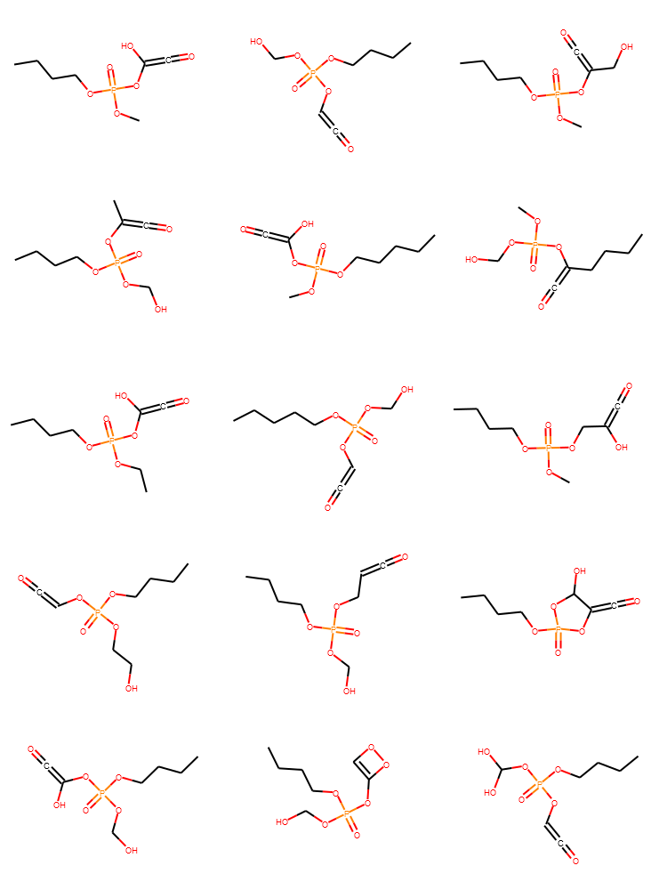

```python
DBall_OMG_ready_henry = pd.read_csv((Projectdir + '\\OMG readys\\DB\\DBall_OMG_readybiodeg_henry.txt'), sep="\t", header=None,
                          names=["Bond est henry", "SMILES"])
print('Total number of ready biodegradable molecules considered:', len(DBall_OMG_ready_henry.index))
higher_than_original(DBall_OMG_ready_henry[DBall_OMG_ready_henry['Bond est henry']!= 'Incomplete'], 'Bond est henry','tibp',tibp_henry)
print('For the following structures, no value could be estimated by HENRYWIN model. Output was \'Incomplete\':')
drawsmileslist(DBall_OMG_ready_henry[DBall_OMG_ready_henry['Bond est henry']== 'Incomplete']['SMILES'])
```

### Bioconcentration, Bioaccumulation factors

Estimated with US EPA EpiSuite

```python
tibp_bioconc = pd.read_csv((Projectdir + '\\tibp\\tibp_bioconc.txt'), sep="\t", header=None,
                          names=["BCF", "log BCF", "Bio Half-life", "log Bio Half-life",
                                 "kM rate const", "BAF upper trophic", "log BAF upper trophic",
                                 "log BAF middle trophic", "log BAF lower trophic", "SMILES"])
tibp_bioconc
```

|  | BCF | log BCF | Bio Half-life | log Bio Half-life | kM rate const | BAF upper trophic | log BAF upper trophic | log BAF middle trophic | log BAF lower trophic | SMILES |
| --- | --- | --- | --- | --- | --- | --- | --- | --- | --- | --- |
| 0 | 16.44 | 1.22 | 0.179 | -0.7479 | 3.879 | 64.1495 | 1.8072 | 1.8762 | 1.8903 | CC(C)COP(=O)(OCC(C)C)OCC(C)C |

```python
all_OMG_ready_bioconc = pd.read_csv((Projectdir + '\\OMG readys\\all_OMG_readybiodeg_bioconc.txt'), sep="\t", header=None,
                          names=["BCF", "log BCF", "Bio Half-life", "log Bio Half-life",
                                 "kM rate const", "BAF upper trophic", "log BAF upper trophic",
                                 "log BAF middle trophic", "log BAF lower trophic", "SMILES"])

print('Total number of ready biodegradable molecules considered:', len(all_OMG_ready_bioconc.index))
higher_than_original(all_OMG_ready_bioconc, 'BCF','tibp',tibp_bioconc)
```

```
Total number of ready biodegradable molecules considered: 7433
Higher value than  tibp  in BCF :
 15
```

|  | BCF | log BCF | Bio Half-life | log Bio Half-life | kM rate const | BAF upper trophic | log BAF upper trophic | log BAF middle trophic | log BAF lower trophic | SMILES |
| --- | --- | --- | --- | --- | --- | --- | --- | --- | --- | --- |
| 6 | 22.98 | 1.36 | 0.235 | -0.6284 | 2.9460 | 87.4948 | 1.9420 | 2.0227 | 2.0429 | CCCCCCOP(=O)(OC)OCCCCC |
| 7 | 22.98 | 1.36 | 0.235 | -0.6284 | 2.9460 | 87.4948 | 1.9420 | 2.0227 | 2.0429 | CCCCCCCOP(=O)(OC)OCCCC |
| 8 | 22.98 | 1.36 | 0.235 | -0.6284 | 2.9460 | 87.4948 | 1.9420 | 2.0227 | 2.0429 | CCCCCOP(=O)(OCC)OCCCCC |
| 9 | 22.98 | 1.36 | 0.235 | -0.6284 | 2.9460 | 87.4948 | 1.9420 | 2.0227 | 2.0429 | CCCCCCOP(=O)(OCC)OCCCC |
| 10 | 30.29 | 1.48 | 0.289 | -0.5384 | 2.3950 | 69.6505 | 1.8429 | 1.9496 | 1.9821 | CCCCOP(=O)(OCCCC)OCCCC |
| 11 | 30.29 | 1.48 | 0.268 | -0.5725 | 2.5900 | 69.6505 | 1.8429 | 1.9496 | 1.9821 | CCCCCOP(=O)(OCCC)OCCCC |
| 43 | 19.20 | 1.28 | 0.917 | -0.0376 | 0.7559 | 351.1471 | 2.5455 | 2.8052 | 3.1348 | CCCCCCOP(=O)(OCCCCC)OCCCCC |
| 44 | 19.20 | 1.28 | 0.917 | -0.0376 | 0.7559 | 351.1471 | 2.5455 | 2.8052 | 3.1348 | CCCCCCOP(=O)(OCCCC)OCCCCCC |
| 45 | 19.20 | 1.28 | 0.917 | -0.0376 | 0.7559 | 351.1471 | 2.5455 | 2.8052 | 3.1348 | CCCCCCCOP(=O)(OCCCC)OCCCCC |
| 46 | 19.20 | 1.28 | 0.917 | -0.0376 | 0.7559 | 351.1471 | 2.5455 | 2.8052 | 3.1348 | CCCCCCCCOP(=O)(OCCCC)OCCCC |
| 47 | 40.48 | 1.61 | 1.260 | 0.1015 | 0.5487 | 436.3788 | 2.6399 | 3.1154 | 3.5910 | CCCCCCOP(=O)(OCCCCC)OCCCCCC |
| 48 | 40.48 | 1.61 | 1.260 | 0.1015 | 0.5487 | 436.3788 | 2.6399 | 3.1154 | 3.5910 | CCCCCCCOP(=O)(OCCCCC)OCCCCC |
| 49 | 40.48 | 1.61 | 1.260 | 0.1015 | 0.5487 | 436.3788 | 2.6399 | 3.1154 | 3.5910 | CCCCCCCOP(=O)(OCCCC)OCCCCCC |
| 50 | 40.48 | 1.61 | 1.260 | 0.1015 | 0.5487 | 436.3788 | 2.6399 | 3.1154 | 3.5910 | CCCCCCCCOP(=O)(OCCCC)OCCCCC |
| 51 | 40.48 | 1.61 | 1.260 | 0.1015 | 0.5487 | 436.3788 | 2.6399 | 3.1154 | 3.5910 | CCCCCCCCCOP(=O)(OCCCC)OCCCC |

```python
DBall_OMG_ready_bioconc = pd.read_csv((Projectdir + '\\OMG readys\\DB\\DBall_OMG_readybiodeg_bioconc.txt'), sep="\t", header=None,
                          names=["BCF", "log BCF", "Bio Half-life", "log Bio Half-life",
                                 "kM rate const", "BAF upper trophic", "log BAF upper trophic",
                                 "log BAF middle trophic", "log BAF lower trophic", "SMILES"])

print('Total number of ready biodegradable molecules considered:', len(DBall_OMG_ready_bioconc.index))
higher_than_original(DBall_OMG_ready_bioconc, 'BCF','tibp',tibp_bioconc)
```

```
Total number of ready biodegradable molecules considered: 38580
Higher value than  tibp  in BCF :
 3
```

|  | BCF | log BCF | Bio Half-life | log Bio Half-life | kM rate const | BAF upper trophic | log BAF upper trophic | log BAF middle trophic | log BAF lower trophic | SMILES |
| --- | --- | --- | --- | --- | --- | --- | --- | --- | --- | --- |
| 3 | 17.33 | 1.24 | 0.144 | -0.8408 | 4.804 | 54.0931 | 1.7331 | 1.8162 | 1.8359 | CCCCCCOP1(=O)OCC(CCCC)O1 |
| 4 | 17.33 | 1.24 | 0.144 | -0.8408 | 4.804 | 54.0931 | 1.7331 | 1.8162 | 1.8359 | CCCCCOP1(=O)OCC(CCCCC)O1 |
| 5 | 17.33 | 1.24 | 0.144 | -0.8408 | 4.804 | 54.0931 | 1.7331 | 1.8162 | 1.8359 | CCCCCCC1COP(=O)(OCCCC)O1 |

### Soil adsoption coefficient Koc

Estimated with US EPA EpiSuite

log Koc < 1 highly mobile,  
log Koc > 5 immobile https://www.chemsafetypro.com/Topics/CRA/Mobility_Classification_of_Chemicals_in_Soil.html

```python
tibp_koc = pd.read_csv((Projectdir + '\\tibp\\tibp_koc.txt'), sep="\t", header=None,
                          names=["Koc", "SMILES"])
tibp_koc
```

|  | Koc | SMILES |
| --- | --- | --- |
| 0 | 1398 | CC(C)COP(=O)(OCC(C)C)OCC(C)C |

```python
all_OMG_ready_koc = pd.read_csv((Projectdir + '\\OMG readys\\all_OMG_readybiodeg_koc.txt'), sep="\t", header=None,
                          names=["Koc", "SMILES"])
print('Total number of ready biodegradable molecules considered:', len(all_OMG_ready_koc.index))
higher_than_original(all_OMG_ready_koc, 'Koc','tibp',tibp_koc)
```

```
Total number of ready biodegradable molecules considered: 7433
Higher value than  tibp  in Koc :
 50
```

|  | Koc | SMILES |
| --- | --- | --- |
| 6 | 2350.0 | CCCCCCOP(=O)(OC)OCCCCC |
| 7 | 2350.0 | CCCCCCCOP(=O)(OC)OCCCC |
| 8 | 2350.0 | CCCCCOP(=O)(OCC)OCCCCC |
| 9 | 2350.0 | CCCCCCOP(=O)(OCC)OCCCC |
| 10 | 2350.0 | CCCCOP(=O)(OCCCC)OCCCC |
| 11 | 2350.0 | CCCCCOP(=O)(OCCC)OCCCC |
| 12 | 4283.0 | CCCCCCOP(=O)(OC)OCCCCCC |
| 13 | 4283.0 | CCCCCCCOP(=O)(OC)OCCCCC |
| 14 | 4283.0 | CCCCCCCCOP(=O)(OC)OCCCC |
| 15 | 4283.0 | CCCCCCOP(=O)(OCC)OCCCCC |
| 16 | 4283.0 | CCCCCCCOP(=O)(OCC)OCCCC |
| 17 | 4283.0 | CCCCCOP(=O)(OCCCC)OCCCC |
| 18 | 4283.0 | CCCCCOP(=O)(OCCC)OCCCCC |
| 19 | 4283.0 | CCCCCCOP(=O)(OCCC)OCCCC |
| 20 | 7806.0 | CCCCCCCCCOP(=O)(OC)OCCCC |
| 21 | 7806.0 | CCCCCCCOP(=O)(OC)OCCCCCC |
| 22 | 7806.0 | CCCCCCCCOP(=O)(OC)OCCCCC |
| 23 | 7806.0 | CCCCCOP(=O)(OCCCC)OCCCCC |
| 24 | 7806.0 | CCCCCCOP(=O)(OCCCC)OCCCC |
| 25 | 7806.0 | CCCCCCOP(=O)(OCCC)OCCCCC |
| 26 | 7806.0 | CCCCCCCOP(=O)(OCCC)OCCCC |
| 27 | 7806.0 | CCCCCCCOP(=O)(OCC)OCCCCC |
| 28 | 7806.0 | CCCCCCCCOP(=O)(OCC)OCCCC |
| 29 | 7806.0 | CCCCCCOP(=O)(OCC)OCCCCCC |
| 30 | 14230.0 | CCCCCCCCCCOP(=O)(OC)OCCCC |
| 31 | 14230.0 | CCCCCCCCCOP(=O)(OC)OCCCCC |
| 32 | 14230.0 | CCCCCCCOP(=O)(OC)OCCCCCCC |
| 33 | 14230.0 | CCCCCCCCOP(=O)(OC)OCCCCCC |
| 34 | 14230.0 | CCCCCCCOP(=O)(OCC)OCCCCCC |
| 35 | 14230.0 | CCCCCCCCOP(=O)(OCC)OCCCCC |
| 36 | 14230.0 | CCCCCCCCCOP(=O)(OCC)OCCCC |
| 37 | 14230.0 | CCCCCCOP(=O)(OCCCC)OCCCCC |
| 38 | 14230.0 | CCCCCOP(=O)(OCCCCC)OCCCCC |
| 39 | 14230.0 | CCCCCCCOP(=O)(OCCCC)OCCCC |
| 40 | 14230.0 | CCCCCCCOP(=O)(OCCC)OCCCCC |
| 41 | 14230.0 | CCCCCCCCOP(=O)(OCCC)OCCCC |
| 42 | 14230.0 | CCCCCCOP(=O)(OCCC)OCCCCCC |
| 43 | 25920.0 | CCCCCCOP(=O)(OCCCCC)OCCCCC |
| 44 | 25920.0 | CCCCCCOP(=O)(OCCCC)OCCCCCC |
| 45 | 25920.0 | CCCCCCCOP(=O)(OCCCC)OCCCCC |
| 46 | 25920.0 | CCCCCCCCOP(=O)(OCCCC)OCCCC |
| 47 | 47250.0 | CCCCCCOP(=O)(OCCCCC)OCCCCCC |
| 48 | 47250.0 | CCCCCCCOP(=O)(OCCCCC)OCCCCC |
| 49 | 47250.0 | CCCCCCCOP(=O)(OCCCC)OCCCCCC |
| 50 | 47250.0 | CCCCCCCCOP(=O)(OCCCC)OCCCCC |
| 51 | 47250.0 | CCCCCCCCCOP(=O)(OCCCC)OCCCC |
| 58 | 1440.0 | CCCCCOP(=O)(OCN)OCCCCC |
| 59 | 1440.0 | CCCCCCOP(=O)(OCN)OCCCC |
| 62 | 1440.0 | CCCCOP(=O)(OCCCC)OCCCN |
| 63 | 1440.0 | CCCCCOP(=O)(OCCN)OCCCC |

```python
DBall_OMG_ready_koc = pd.read_csv((Projectdir + '\\OMG readys\\DB\\DBall_OMG_readybiodeg_koc.txt'), sep="\t", header=None,
                          names=["Koc", "SMILES"])
print('Total number of ready biodegradable molecules considered:', len(DBall_OMG_ready_koc.index))
higher_than_original(DBall_OMG_ready_koc, 'Koc','tibp',tibp_koc)
```

```
Total number of ready biodegradable molecules considered: 38580
Higher value than  tibp  in Koc :
 3
```

|  | Koc | SMILES |
| --- | --- | --- |
| 3 | 2401.0 | CCCCCCOP1(=O)OCC(CCCC)O1 |
| 4 | 2401.0 | CCCCCOP1(=O)OCC(CCCCC)O1 |
| 5 | 2401.0 | CCCCCCC1COP(=O)(OCCCC)O1 |

### Atmospheric OH reaction rate

estimated with US EPA EpiSuite

rate constant for the atmospheric, gas-phase reaction between photochemically produced hydroxyl radicals and organic chemicals  
unit: cm3/molecule-sec  
The half-life in the troposphere, t½ = 0.693/kOH[OH] ; (Atkinson and Arey, 2003) have suggested 2.0 × 106 molecules (radicals)/cm3 12-hour daylight hydroxyl radical concentration. (AOPwin manual)

```python
tibp_OHrate = pd.read_csv((Projectdir + '\\tibp\\tibp_OHrate.txt'), sep="\t", header=None,
                          names=["kOH", "SMILES"])
tibp_OHrate
```

|  | kOH | SMILES |
| --- | --- | --- |
| 0 | 7.881471e-11 | CC(C)COP(=O)(OCC(C)C)OCC(C)C |

```python
all_OMG_ready_OHrate = pd.read_csv((Projectdir + '\\OMG readys\\all_OMG_readybiodeg_OHrate.txt'), sep="\t", header=None,
                          names=["kOH", "SMILES"])
print('Total number of ready biodegradable molecules considered:', len(all_OMG_ready_OHrate.index))
higher_than_original(all_OMG_ready_OHrate, 'kOH','tibp',tibp_OHrate)
```

```
Total number of ready biodegradable molecules considered: 7433
Higher value than  tibp  in kOH :
 6795
```

|  | kOH | SMILES |
| --- | --- | --- |
| 10 | 7.883987e-11 | CCCCOP(=O)(OCCCC)OCCCC |
| 11 | 7.883987e-11 | CCCCCOP(=O)(OCCC)OCCCC |
| 17 | 8.025292e-11 | CCCCCOP(=O)(OCCCC)OCCCC |
| 18 | 8.025292e-11 | CCCCCOP(=O)(OCCC)OCCCCC |
| 19 | 8.025292e-11 | CCCCCCOP(=O)(OCCC)OCCCC |
| ... | ... | ... |
| 7423 | 1.112228e-10 | CCCCC(O)CC(OP(=O)(OC)OC)C(O)O |
| 7429 | 2.707747e-10 | CCCCC(C)COCOP(=O)(OCO)OCO |
| 7430 | 2.744677e-10 | CCCCC(CC)OCOP(=O)(OCO)OCO |
| 7431 | 2.713840e-10 | CCCCCC(C)OCOP(=O)(OCO)OCO |
| 7432 | 2.676896e-10 | CCCCCCCOCOP(=O)(OCO)OCO |

6795 rows × 2 columns

```python
DBall_OMG_ready_OHrate = pd.read_csv((Projectdir + '\\OMG readys\\DB\\DBall_OMG_readybiodeg_kOH.txt'), sep="\t", header=None,
                          names=["kOH", "SMILES"])
print('Total number of ready biodegradable molecules considered:', len(DBall_OMG_ready_OHrate.index))
higher_than_original(DBall_OMG_ready_OHrate, 'kOH','tibp',tibp_OHrate)
```

```
Total number of ready biodegradable molecules considered: 38580
Higher value than  tibp  in kOH :
 37332
```

|  | kOH | SMILES |
| --- | --- | --- |
| 1 | 8.541527e-11 | CCCCCOP1(=O)OCC(CCCC)O1 |
| 2 | 8.541527e-11 | CCCCCC1COP(=O)(OCCCC)O1 |
| 3 | 8.682831e-11 | CCCCCCOP1(=O)OCC(CCCC)O1 |
| 4 | 8.682832e-11 | CCCCCOP1(=O)OCC(CCCCC)O1 |
| 5 | 8.682832e-11 | CCCCCCC1COP(=O)(OCCCC)O1 |
| ... | ... | ... |
| 38575 | 4.451723e-10 | CC(O)OP1(=O)OC(O)C#CC(O)O1 |
| 38576 | 5.380687e-10 | O=P12OC(O)C=C(CC(O)O1)C(O)O2 |
| 38577 | 3.909951e-10 | O=P12OC(O)C3C(C(O)O1)C3C(O)O2 |
| 38578 | 1.402143e-10 | O=C(O)COP1(=O)OCC(=CO)CO1 |
| 38579 | 1.402143e-10 | O=C(O)COP1(=O)OCC=C(O)CO1 |

37332 rows × 2 columns

## One big df with all properties

One big dataframe with all properties should be created to be used for further multi-parameter analysis.

### tibp

```python
all_tibp_model_dfs = [tibp_OHrate,tibp_henry,tibp_koc,tibp_bpmpvp,
                      tibp_waternt,tibp_wskow,tibp_bioconc, tibpbiowin]
tibp_allprops = reduce(lambda left,right: pd.merge(left,right,on='SMILES'), all_tibp_model_dfs)
tibp_allprops['log koc']= np.log10(tibp_allprops['Koc'])
tibp_allprops['Wat Sol mg/L']
```

[output not shown]

```python
tibp_allprops[['SMILES','bp degC','mp degC','vp mmHg',
                 'WatSol mg/L','WSol mg/L','log Kow','log koc','kOH','Bond est henry','Biowin1', 'Biowin2', 'Biowin3', 'Biowin4', 'Biowin5', 'Biowin6', 'Biowin7']]
```

|  | SMILES | bp degC | mp degC | vp mmHg | WatSol mg/L | WSol mg/L | log Kow | log koc | kOH | Bond est henry | Biowin1 | Biowin2 | Biowin3 | Biowin4 | Biowin5 | Biowin6 | Biowin7 |
| --- | --- | --- | --- | --- | --- | --- | --- | --- | --- | --- | --- | --- | --- | --- | --- | --- | --- |
| 0 | CC(C)COP(=O)(OCC(C)C)OCC(C)C | 302.2 | 16.43 | 0.0128 | 475.57 | 16.22 | 3.6 | 3.145507 | 7.881471e-11 | 0.000003 | 0.9347 | 1.0 | 2.7644 | 3.9289 | 0.0732 | 0.0509 | 0.4661 |

```python
#save df to .txt
#tibp_allprops.to_csv('C:\\Users\\Hannah\\Documents\\Master UvA\\master project\\OMG\\selection\\tibp_props.txt',
#                               header=True, index=True, sep='\t', mode='a')
```

### Saturated

```python
all_OMG_ready_model_dfs = [all_OMG_ready_OHrate,all_OMG_ready_henry,all_OMG_ready_koc,all_OMG_ready_bpmpvp,
                      all_OMG_ready_waternt, all_OMG_ready_wskow,all_OMG_ready_bioconc, all_OMG_ready_biowin]
all_OMG_ready_allprops = reduce(lambda left,right: pd.merge(left,right,on='SMILES'), all_OMG_ready_model_dfs)
all_OMG_ready_allprops.head()
```

|  | kOH | SMILES | Bond est henry | Koc | bp degC | mp degC | vp mmHg | log WatSol mol/L | WatSol mg/L | WSol mg/L | ... | log BAF upper trophic | log BAF middle trophic | log BAF lower trophic | Biowin1 | Biowin2 | Biowin3 | Biowin4 | Biowin5 | Biowin6 | Biowin7 |
| --- | --- | --- | --- | --- | --- | --- | --- | --- | --- | --- | --- | --- | --- | --- | --- | --- | --- | --- | --- | --- | --- |
| 0 | 7.187419e-11 | CCCCOP(=O)(OCC)OCCCC | 0.000002 | 707.6 | 299.40 | 37.50 | 0.001550 | -2.3469 | 1071.9 | 103.9 | ... | 1.4661 | 1.4462 | 1.4285 | 1.1649 | 1.0 | 3.423 | 4.5075 | 0.5052 | 0.4607 | 0.6709 |
| 1 | 5.676096e-11 | CCCCCOP(=O)(OC)OCCCC | 0.000002 | 707.6 | 299.40 | 37.50 | 0.001550 | -2.3469 | 1071.9 | 103.9 | ... | 1.4661 | 1.4462 | 1.4285 | 1.1649 | 1.0 | 3.423 | 4.5075 | 0.5052 | 0.4607 | 0.6709 |
| 2 | 5.817401e-11 | CCCCCOP(=O)(OC)OCCCCC | 0.000002 | 1290.0 | 313.67 | 55.19 | 0.000495 | -2.8839 | 329.6 | 33.1 | ... | 1.7339 | 1.7684 | 1.7688 | 1.1582 | 1.0 | 3.392 | 4.4872 | 0.5128 | 0.4668 | 0.6968 |
| 3 | 5.817401e-11 | CCCCCCOP(=O)(OC)OCCCC | 0.000002 | 1290.0 | 313.67 | 55.19 | 0.000495 | -2.8839 | 329.6 | 33.1 | ... | 1.7339 | 1.7684 | 1.7688 | 1.1582 | 1.0 | 3.392 | 4.4872 | 0.5128 | 0.4668 | 0.6968 |
| 4 | 7.742683e-11 | CCCCOP(=O)(OCCC)OCCCC | 0.000002 | 1290.0 | 313.67 | 55.19 | 0.000495 | -2.8839 | 329.6 | 33.1 | ... | 1.7339 | 1.7684 | 1.7688 | 1.1582 | 1.0 | 3.392 | 4.4872 | 0.5128 | 0.4668 | 0.6968 |

5 rows × 28 columns

```python
#Check for ether structures in dataset
Ether_all = filterinSmartsdf(all_OMG_ready_biowin, Ethersmarts)
#drawsmileslist(Ether_all['SMILES'])
```

```
817 structures with specified substructure (smarts) were selected.
Molecules without specified group filtered out:  6616
```

```python
#filter out terminal OH groups
filteroutSmartsdf(all_OMG_ready_biowin, OHsmarts)
```

```
7367 structures with specified substructure (smarts) were filtered out.
Molecules without specified group in new DataFrame:  66
```

|  | Biowin1 | Biowin2 | Biowin3 | Biowin4 | Biowin5 | Biowin6 | Biowin7 | SMILES |
| --- | --- | --- | --- | --- | --- | --- | --- | --- |
| 0 | 1.1649 | 1.0 | 3.4230 | 4.5075 | 0.5052 | 0.4607 | 0.6709 | CCCCOP(=O)(OCC)OCCCC |
| 1 | 1.1649 | 1.0 | 3.4230 | 4.5075 | 0.5052 | 0.4607 | 0.6709 | CCCCCOP(=O)(OC)OCCCC |
| 2 | 1.1582 | 1.0 | 3.3920 | 4.4872 | 0.5128 | 0.4668 | 0.6968 | CCCCCOP(=O)(OC)OCCCCC |
| 3 | 1.1582 | 1.0 | 3.3920 | 4.4872 | 0.5128 | 0.4668 | 0.6968 | CCCCCCOP(=O)(OC)OCCCC |
| 4 | 1.1582 | 1.0 | 3.3920 | 4.4872 | 0.5128 | 0.4668 | 0.6968 | CCCCOP(=O)(OCCC)OCCCC |
| ... | ... | ... | ... | ... | ... | ... | ... | ... |
| 61 | 1.3049 | 1.0 | 3.3833 | 4.5088 | 0.5015 | 0.2992 | 0.8741 | CCCCOP(=O)(OCCCC)OCNCC |
| 62 | 1.3049 | 1.0 | 3.3833 | 4.5088 | 0.5505 | 0.3915 | 0.9797 | CCCCOP(=O)(OCCCC)OCCCN |
| 63 | 1.3049 | 1.0 | 3.3833 | 4.5088 | 0.5505 | 0.3915 | 0.9797 | CCCCCOP(=O)(OCCN)OCCCC |
| 64 | 1.3049 | 1.0 | 3.3833 | 4.5088 | 0.5015 | 0.2992 | 0.8741 | CCCCOP(=O)(OCCCC)OCCNC |
| 65 | 1.3049 | 1.0 | 3.3833 | 4.5088 | 0.5015 | 0.2992 | 0.8741 | CCCCNCCOP(=O)(OC)OCCCC |

66 rows × 8 columns

### DB

```python
DB_OMG_ready_model_dfs = [DBall_OMG_ready_OHrate,DBall_OMG_ready_henry,DBall_OMG_ready_koc,DBall_OMG_ready_bpmpvp,
                      DBall_OMG_ready_waternt, DBall_OMG_ready_wskow,DBall_OMG_ready_bioconc, DBall_OMG_ready_biowin]
DB_OMG_ready_allprops = reduce(lambda left,right: pd.merge(left,right,on='SMILES'), DB_OMG_ready_model_dfs)
DB_OMG_ready_allprops.head()
```

|  | kOH | SMILES | Bond est henry | Koc | bp degC | mp degC | vp mmHg | log WatSol mol/L | WatSol mg/L | WSol mg/L | ... | log BAF upper trophic | log BAF middle trophic | log BAF lower trophic | Biowin1 | Biowin2 | Biowin3 | Biowin4 | Biowin5 | Biowin6 | Biowin7 |
| --- | --- | --- | --- | --- | --- | --- | --- | --- | --- | --- | --- | --- | --- | --- | --- | --- | --- | --- | --- | --- | --- |
| 0 | 5.642500e-11 | CCCCOP1(=O)OCCO1 | 2.57E-007 | 71.11 | 251.41 | 22.51 | 0.025300 | -0.2179 | 109060.00 | 12350.00 | ... | 0.0474 | 0.0597 | 0.0600 | 1.0842 | 1.0 | 3.2532 | 4.3223 | 0.5190 | 0.5589 | 0.8037 |
| 1 | 8.541527e-11 | CCCCCOP1(=O)OCC(CCCC)O1 | 1.06E-006 | 1317.00 | 323.44 | 69.59 | 0.000212 | -2.8850 | 326.17 | 48.95 | ... | 1.5245 | 1.5644 | 1.5663 | 1.1592 | 1.0 | 3.3965 | 4.4901 | 0.5012 | 0.3973 | 0.6699 |
| 2 | 8.541527e-11 | CCCCCC1COP(=O)(OCCCC)O1 | 1.06E-006 | 1317.00 | 323.44 | 69.59 | 0.000212 | -2.8850 | 326.17 | 48.95 | ... | 1.5245 | 1.5644 | 1.5663 | 1.1592 | 1.0 | 3.3965 | 4.4901 | 0.5012 | 0.3973 | 0.6699 |
| 3 | 8.682831e-11 | CCCCCCOP1(=O)OCC(CCCC)O1 | 1.41E-006 | 2401.00 | 336.15 | 78.81 | 0.000086 | -3.4220 | 100.02 | 15.56 | ... | 1.7331 | 1.8162 | 1.8359 | 1.1525 | 1.0 | 3.3655 | 4.4699 | 0.5089 | 0.4032 | 0.6958 |
| 4 | 8.682832e-11 | CCCCCOP1(=O)OCC(CCCCC)O1 | 1.41E-006 | 2401.00 | 336.15 | 78.81 | 0.000086 | -3.4220 | 100.02 | 15.56 | ... | 1.7331 | 1.8162 | 1.8359 | 1.1525 | 1.0 | 3.3655 | 4.4699 | 0.5089 | 0.4032 | 0.6958 |

5 rows × 28 columns

### ALL - DB and saturated all properties

The saturated and DB series are combined into one dataset

```python
ALLDB_OMG_ready_allprops = all_OMG_ready_allprops.append(DB_OMG_ready_allprops, ignore_index=True)
print('No SMILES double:',len(ALLDB_OMG_ready_allprops['SMILES'])==len(set(ALLDB_OMG_ready_allprops['SMILES'])))
print('Rows match addition of dfs:',len(ALLDB_OMG_ready_allprops['SMILES'])== (len(DB_OMG_ready_allprops['SMILES'])+len(all_OMG_ready_allprops)))
#No Smiles double to check proper addition of dataframes, smiles not unique, no test for uniqueness of molecules, but they should be as generated by OMG
ALLDB_OMG_ready_allprops.columns
```

```
No SMILES double: True
Rows match addition of dfs: True
```

```
Index(['kOH', 'SMILES', 'Bond est henry', 'Koc', 'bp degC', 'mp degC',
       'vp mmHg', 'log WatSol mol/L', 'WatSol mg/L', 'WSol mg/L',
       'log WSol mol/L', 'log Kow', 'BCF', 'log BCF', 'Bio Half-life',
       'log Bio Half-life', 'kM rate const', 'BAF upper trophic',
       'log BAF upper trophic', 'log BAF middle trophic',
       'log BAF lower trophic', 'Biowin1', 'Biowin2', 'Biowin3', 'Biowin4',
       'Biowin5', 'Biowin6', 'Biowin7'],
      dtype='object')
```

```python
#Check: filtering out terminal OH
ALLiDB_noOH = filteroutSmartsdf(ALLDB_OMG_ready_allprops, OHsmarts)
```

```
45864 structures with specified substructure (smarts) were filtered out.
Molecules without specified group in new DataFrame:  149
```

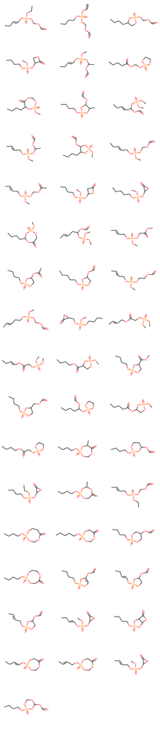

```python
#Inspect remaining molecuels
drawsmileslist(ALLiDB_noOH['SMILES'][100:149])
```

```python
#store the dataframe as .txt
#ALLDB_OMG_ready_allprops.to_csv('C:\\Users\\Hannah\\Documents\\Master UvA\\master project\\OMG\\OMG readys\\ALLDB_OMG_ready_allprops.txt',
#                                header=True, index=True, sep='\t', mode='a')
```

```python
#Create a .txt with just SMILES (used as input for QSAR models)
#writetxt(ALLDB_OMG_ready_allprops['SMILES'],'ALLDB_OMG_ready_SMILES','C:\\Users\\Hannah\\Documents\\Master UvA\\master project\\OMG\\OMG readys')
```

```python
#some try-outs to get a feel for the dataset
ALLDB_ready_logKowlower45 = ALLDB_OMG_ready_allprops[ALLDB_OMG_ready_allprops['log Kow']<4.5]
```

```python
ALLDB_ready_logKowlower45[ALLDB_ready_logKowlower45['BCF']<2000]
```

|  | kOH | SMILES | Bond est henry | Koc | bp degC | mp degC | vp mmHg | log WatSol mol/L | WatSol mg/L | WSol mg/L | ... | log BAF upper trophic | log BAF middle trophic | log BAF lower trophic | Biowin1 | Biowin2 | Biowin3 | Biowin4 | Biowin5 | Biowin6 | Biowin7 |
| --- | --- | --- | --- | --- | --- | --- | --- | --- | --- | --- | --- | --- | --- | --- | --- | --- | --- | --- | --- | --- | --- |
| 0 | 7.187419e-11 | CCCCOP(=O)(OCC)OCCCC | 1.81e-06 | 707.6 | 299.40 | 37.50 | 1.550000e-03 | -2.3469 | 1071.9 | 103.9 | ... | 1.4661 | 1.4462 | 1.4285 | 1.1649 | 1.0 | 3.4230 | 4.5075 | 0.5052 | 0.4607 | 0.6709 |
| 1 | 5.676096e-11 | CCCCCOP(=O)(OC)OCCCC | 1.81e-06 | 707.6 | 299.40 | 37.50 | 1.550000e-03 | -2.3469 | 1071.9 | 103.9 | ... | 1.4661 | 1.4462 | 1.4285 | 1.1649 | 1.0 | 3.4230 | 4.5075 | 0.5052 | 0.4607 | 0.6709 |
| 2 | 5.817401e-11 | CCCCCOP(=O)(OC)OCCCCC | 2.4e-06 | 1290.0 | 313.67 | 55.19 | 4.950000e-04 | -2.8839 | 329.6 | 33.1 | ... | 1.7339 | 1.7684 | 1.7688 | 1.1582 | 1.0 | 3.3920 | 4.4872 | 0.5128 | 0.4668 | 0.6968 |
| 3 | 5.817401e-11 | CCCCCCOP(=O)(OC)OCCCC | 2.4e-06 | 1290.0 | 313.67 | 55.19 | 4.950000e-04 | -2.8839 | 329.6 | 33.1 | ... | 1.7339 | 1.7684 | 1.7688 | 1.1582 | 1.0 | 3.3920 | 4.4872 | 0.5128 | 0.4668 | 0.6968 |
| 4 | 7.742683e-11 | CCCCOP(=O)(OCCC)OCCCC | 2.4e-06 | 1290.0 | 313.67 | 55.19 | 4.950000e-04 | -2.8839 | 329.6 | 33.1 | ... | 1.7339 | 1.7684 | 1.7688 | 1.1582 | 1.0 | 3.3920 | 4.4872 | 0.5128 | 0.4668 | 0.6968 |
| ... | ... | ... | ... | ... | ... | ... | ... | ... | ... | ... | ... | ... | ... | ... | ... | ... | ... | ... | ... | ... | ... |
| 46008 | 4.451723e-10 | CC(O)OP1(=O)OC(O)C#CC(O)O1 | 7.84E-016 | 10.0 | 383.99 | 83.89 | 2.870000e-08 | 0.6495 | 1000000.0 | 1000000.0 | ... | -0.0491 | -0.0308 | -0.0268 | 1.4310 | 1.0 | 3.3376 | 4.3781 | 0.6582 | 0.4650 | 1.5949 |
| 46009 | 5.380687e-10 | O=P12OC(O)C=C(CC(O)O1)C(O)O2 | 5.75E-015 | 10.0 | 389.89 | 84.75 | 1.830000e-08 | 0.6495 | 1000000.0 | 1000000.0 | ... | -0.0491 | -0.0308 | -0.0268 | 1.4310 | 1.0 | 3.3376 | 4.3781 | 0.7468 | 0.5189 | 1.6862 |
| 46010 | 3.909951e-10 | O=P12OC(O)C3C(C(O)O1)C3C(O)O2 | 2.44E-015 | 10.0 | 381.42 | 83.51 | 3.480000e-08 | 0.6495 | 1000000.0 | 1000000.0 | ... | -0.0491 | -0.0308 | -0.0268 | 1.4310 | 1.0 | 3.3376 | 4.3781 | 0.7582 | 0.3594 | 1.9981 |
| 46011 | 1.402143e-10 | O=C(O)COP1(=O)OCC(=CO)CO1 | 2.60E-015 | 10.0 | 395.63 | 85.59 | 6.530000e-08 | 0.6495 | 1000000.0 | 1000000.0 | ... | -0.0489 | -0.0305 | -0.0265 | 1.1862 | 1.0 | 3.3822 | 4.5048 | 0.6375 | 0.5637 | 1.3951 |
| 46012 | 1.402143e-10 | O=C(O)COP1(=O)OCC=C(O)CO1 | 2.60E-015 | 10.0 | 395.67 | 85.59 | 6.510000e-08 | 0.6495 | 1000000.0 | 1000000.0 | ... | -0.0489 | -0.0305 | -0.0265 | 1.1862 | 1.0 | 3.3822 | 4.5048 | 0.6375 | 0.5637 | 1.3951 |

45981 rows × 28 columns

```python
ALLiDB_noOH[ALLiDB_noOH['log Kow']<4.5] #117 out of 149 have low enough log Kow to not be considered bioaccumulative
```

|  | kOH | SMILES | Bond est henry | Koc | bp degC | mp degC | vp mmHg | log WatSol mol/L | WatSol mg/L | WSol mg/L | ... | log BAF upper trophic | log BAF middle trophic | log BAF lower trophic | Biowin1 | Biowin2 | Biowin3 | Biowin4 | Biowin5 | Biowin6 | Biowin7 |
| --- | --- | --- | --- | --- | --- | --- | --- | --- | --- | --- | --- | --- | --- | --- | --- | --- | --- | --- | --- | --- | --- |
| 0 | 7.187419e-11 | CCCCOP(=O)(OCC)OCCCC | 1.81e-06 | 707.60 | 299.40 | 37.50 | 0.001550 | -2.3469 | 1071.9 | 103.9 | ... | 1.4661 | 1.4462 | 1.4285 | 1.1649 | 1.0 | 3.4230 | 4.5075 | 0.5052 | 0.4607 | 0.6709 |
| 1 | 5.676096e-11 | CCCCCOP(=O)(OC)OCCCC | 1.81e-06 | 707.60 | 299.40 | 37.50 | 0.001550 | -2.3469 | 1071.9 | 103.9 | ... | 1.4661 | 1.4462 | 1.4285 | 1.1649 | 1.0 | 3.4230 | 4.5075 | 0.5052 | 0.4607 | 0.6709 |
| 2 | 5.817401e-11 | CCCCCOP(=O)(OC)OCCCCC | 2.4e-06 | 1290.00 | 313.67 | 55.19 | 0.000495 | -2.8839 | 329.6 | 33.1 | ... | 1.7339 | 1.7684 | 1.7688 | 1.1582 | 1.0 | 3.3920 | 4.4872 | 0.5128 | 0.4668 | 0.6968 |
| 3 | 5.817401e-11 | CCCCCCOP(=O)(OC)OCCCC | 2.4e-06 | 1290.00 | 313.67 | 55.19 | 0.000495 | -2.8839 | 329.6 | 33.1 | ... | 1.7339 | 1.7684 | 1.7688 | 1.1582 | 1.0 | 3.3920 | 4.4872 | 0.5128 | 0.4668 | 0.6968 |
| 4 | 7.742683e-11 | CCCCOP(=O)(OCCC)OCCCC | 2.4e-06 | 1290.00 | 313.67 | 55.19 | 0.000495 | -2.8839 | 329.6 | 33.1 | ... | 1.7339 | 1.7684 | 1.7688 | 1.1582 | 1.0 | 3.3920 | 4.4872 | 0.5128 | 0.4668 | 0.6968 |
| ... | ... | ... | ... | ... | ... | ... | ... | ... | ... | ... | ... | ... | ... | ... | ... | ... | ... | ... | ... | ... | ... |
| 15017 | 4.302291e-11 | CCCCOP1(=O)OC2OC(=O)C2O1 | 1.44E-009 | 18.74 | 348.25 | 82.34 | 0.000041 | -0.0376 | 203730.0 | 120500.0 | ... | -0.0470 | -0.0285 | -0.0245 | 1.2383 | 1.0 | 3.3006 | 4.4906 | 0.7233 | 0.6767 | 1.2945 |
| 15021 | 9.407205e-11 | CC/C=C/OP1(=O)OCOC(=O)CO1 | 1.93E-008 | 19.12 | 356.41 | 68.91 | 0.000036 | 0.6534 | 1000000.0 | 56340.0 | ... | -0.0441 | -0.0253 | -0.0212 | 1.2383 | 1.0 | 3.3006 | 4.4906 | 0.6514 | 0.6612 | 0.7766 |
| 15030 | 1.122538e-10 | C/C=C/COP1(=O)OCOC(=O)CO1 | 2.87E-009 | 19.12 | 356.41 | 68.91 | 0.000036 | 0.6534 | 1000000.0 | 56340.0 | ... | -0.0441 | -0.0253 | -0.0212 | 1.2383 | 1.0 | 3.3006 | 4.4906 | 0.6514 | 0.6612 | 0.7766 |
| 15031 | 7.886552e-11 | C/C=C/COP(=O)(OC)OC1OC1=O | 2.87E-009 | 17.98 | 344.42 | 72.74 | 0.000063 | 0.5145 | 726330.0 | 65100.0 | ... | -0.0448 | -0.0261 | -0.0220 | 1.2383 | 1.0 | 3.3006 | 4.4906 | 0.6248 | 0.5214 | 0.9765 |
| 33438 | 5.312319e-10 | CCCCOP1(=O)OCOC(OC=O)O1 | 7.39E-012 | 10.00 | 319.58 | 73.97 | 0.000236 | 0.6195 | 1000000.0 | 596200.0 | ... | -0.0489 | -0.0305 | -0.0265 | 0.8824 | 1.0 | 3.2521 | 4.4549 | 0.6784 | 0.6171 | 0.8778 |

117 rows × 28 columns

### Koa (addition)

The porperty octanol air partition coefficient was added later

```python
ALLDB_OMG_ready_koa = pd.read_csv((Projectdir + '\\OMG readys\\ALLDB_OMG_ready_koa.txt'),
                                  names = ['log Koa','HenryLC atmm3/mol','SMILES'], sep="\t")
ALLDB_OMG_ready_allprops_koa = pd.merge(ALLDB_OMG_ready_allprops, ALLDB_OMG_ready_koa, on='SMILES')
print(ALLDB_OMG_ready_allprops_koa.columns)
```

```
Index(['kOH', 'SMILES', 'Bond est henry', 'Koc', 'bp degC', 'mp degC',
       'vp mmHg', 'log WatSol mol/L', 'WatSol mg/L', 'WSol mg/L',
       'log WSol mol/L', 'log Kow', 'BCF', 'log BCF', 'Bio Half-life',
       'log Bio Half-life', 'kM rate const', 'BAF upper trophic',
       'log BAF upper trophic', 'log BAF middle trophic',
       'log BAF lower trophic', 'Biowin1', 'Biowin2', 'Biowin3', 'Biowin4',
       'Biowin5', 'Biowin6', 'Biowin7', 'log Koa', 'HenryLC atmm3/mol'],
      dtype='object')
```

### VEGA mutagenicity

For the molecules in the dataset the mutagenisity was predicted with the VEGA QSAR model.

VEGA outputs different SMILES that in input, therefore the input smiles are merged on index. Some random checks were made to test if the molecules encoded by the smiles in 'SMILES' and 'vegaSmiles' are the same and to verify that the merging was correct.

```python
all_OMG_ready_mutagenicity = pd.read_csv((Projectdir + '\\OMG readys\\ALLDB_OMG_ready_MUTA_CONSENSUS.txt'),
                                         sep="\t")
all_OMG_ready_smilesin = pd.read_csv((Projectdir + '\\OMG readys\\ALLDB_OMG_ready_SMILES_title.txt'),
                                         sep="\t")
all_OMG_ready_mutagenicity.rename(columns={"SMILES": "vegaSMILES"}, inplace=True)
mutagens = all_OMG_ready_mutagenicity[all_OMG_ready_mutagenicity['Predicted Consensus Mutagen activity']!= 'NON-Mutagenic']
#drawsmileslist(mutagens['SMILES'])
all_OMG_ready_mutagenicity = pd.merge(all_OMG_ready_smilesin,all_OMG_ready_mutagenicity, left_index=True, right_index=True)
all_OMG_ready_mutagenicity
```

|  | SMILES | No. | Id | vegaSMILES | Assessment | Used models | Predicted Consensus Mutagen activity | Mutagenic Score | Non-Mutagenic Score | Model Caesar assessment | Model ISS assessment | Model SarPy assessment | Model KNN assessment | Remarks |
| --- | --- | --- | --- | --- | --- | --- | --- | --- | --- | --- | --- | --- | --- | --- |
| 0 | CCCCOP(=O)(OCC)OCCCC | 1 | Molecule 1 | O=P(OCC)(OCCCC)OCCCC | NON-Mutagenic (Consensus score: 0.6) | 4 | NON-Mutagenic | 0.05 | 0.600 | NON-Mutagenic (good reliability) | Mutagenic (low reliability) | Possible NON-Mutagenic (good reliability) | NON-Mutagenic (moderate reliability) | - |
| 1 | CCCCCOP(=O)(OC)OCCCC | 2 | Molecule 2 | O=P(OC)(OCCCC)OCCCCC | NON-Mutagenic (Consensus score: 0.675) | 4 | NON-Mutagenic | 0.05 | 0.675 | NON-Mutagenic (good reliability) | Mutagenic (low reliability) | NON-Mutagenic (good reliability) | NON-Mutagenic (good reliability) | - |
| 2 | CCCCCOP(=O)(OC)OCCCCC | 3 | Molecule 3 | O=P(OC)(OCCCCC)OCCCCC | NON-Mutagenic (Consensus score: 0.75) | 4 | NON-Mutagenic | 0.00 | 0.750 | NON-Mutagenic (good reliability) | NON-Mutagenic (moderate reliability) | NON-Mutagenic (good reliability) | NON-Mutagenic (moderate reliability) | - |
| 3 | CCCCCCOP(=O)(OC)OCCCC | 4 | Molecule 4 | O=P(OC)(OCCCC)OCCCCCC | NON-Mutagenic (Consensus score: 0.675) | 4 | NON-Mutagenic | 0.05 | 0.675 | NON-Mutagenic (good reliability) | Mutagenic (low reliability) | NON-Mutagenic (good reliability) | NON-Mutagenic (good reliability) | - |
| 4 | CCCCOP(=O)(OCCC)OCCCC | 5 | Molecule 5 | O=P(OCCC)(OCCCC)OCCCC | NON-Mutagenic (Consensus score: 0.6) | 4 | NON-Mutagenic | 0.15 | 0.600 | NON-Mutagenic (good reliability) | Mutagenic (moderate reliability) | Possible NON-Mutagenic (good reliability) | NON-Mutagenic (moderate reliability) | - |
| ... | ... | ... | ... | ... | ... | ... | ... | ... | ... | ... | ... | ... | ... | ... |
| 46008 | CC(O)OP1(=O)OC(O)C#CC(O)O1 | 46009 | Molecule 46009 | O=P1(OC(O)C#CC(O)O1)OC(O)C | NON-Mutagenic (Consensus score: 0.5) | 4 | NON-Mutagenic | 0.00 | 0.500 | NON-Mutagenic (moderate reliability) | NON-Mutagenic (low reliability) | Possible NON-Mutagenic (moderate reliability) | NON-Mutagenic (moderate reliability) | - |
| 46009 | O=P12OC(O)C=C(CC(O)O1)C(O)O2 | 46010 | Molecule 46010 | O=P12(OC(O)C=C(CC(O)O1)C(O)O2) | NON-Mutagenic (Consensus score: 0.6) | 4 | NON-Mutagenic | 0.00 | 0.600 | NON-Mutagenic (moderate reliability) | NON-Mutagenic (moderate reliability) | Possible NON-Mutagenic (moderate reliability) | NON-Mutagenic (moderate reliability) | - |
| 46010 | O=P12OC(O)C3C(C(O)O1)C3C(O)O2 | 46011 | Molecule 46011 | O=P12(OC(O)C3C(C(O)O1)C3(C(O)O2)) | NON-Mutagenic (Consensus score: 0.6) | 4 | NON-Mutagenic | 0.00 | 0.600 | NON-Mutagenic (moderate reliability) | NON-Mutagenic (moderate reliability) | NON-Mutagenic (moderate reliability) | NON-Mutagenic (moderate reliability) | - |
| 46011 | O=C(O)COP1(=O)OCC(=CO)CO1 | 46012 | Molecule 46012 | O=C(O)COP1(=O)(OCC(=CO)CO1) | NON-Mutagenic (Consensus score: 0.35) | 4 | NON-Mutagenic | 0.05 | 0.350 | Mutagenic (low reliability) | NON-Mutagenic (moderate reliability) | Possible NON-Mutagenic (moderate reliability) | NON-Mutagenic (low reliability) | - |
| 46012 | O=C(O)COP1(=O)OCC=C(O)CO1 | 46013 | Molecule 46013 | O=C(O)COP1(=O)(OCC=C(O)CO1) | NON-Mutagenic (Consensus score: 0.45) | 4 | NON-Mutagenic | 0.05 | 0.450 | Mutagenic (low reliability) | NON-Mutagenic (moderate reliability) | Possible NON-Mutagenic (moderate reliability) | NON-Mutagenic (moderate reliability) | - |

46013 rows × 14 columns

```python
#Chem.MolFromSmiles('O=C(O)COP1(=O)OCC=C(O)CO1')
```

```python
#Chem.MolFromSmiles('O=C(O)COP1(=O)(OCC=C(O)CO1)')
```

```python
ALLDB_OMG_ready_allprops_muta = pd.merge(ALLDB_OMG_ready_allprops_koa, all_OMG_ready_mutagenicity, on = 'SMILES')
print(ALLDB_OMG_ready_allprops_muta.columns)
```

```
Index(['kOH', 'SMILES', 'Bond est henry', 'Koc', 'bp degC', 'mp degC',
       'vp mmHg', 'log WatSol mol/L', 'WatSol mg/L', 'WSol mg/L',
       'log WSol mol/L', 'log Kow', 'BCF', 'log BCF', 'Bio Half-life',
       'log Bio Half-life', 'kM rate const', 'BAF upper trophic',
       'log BAF upper trophic', 'log BAF middle trophic',
       'log BAF lower trophic', 'Biowin1', 'Biowin2', 'Biowin3', 'Biowin4',
       'Biowin5', 'Biowin6', 'Biowin7', 'log Koa', 'HenryLC atmm3/mol', 'No.',
       'Id', 'vegaSMILES', 'Assessment', 'Used models',
       'Predicted Consensus Mutagen activity', 'Mutagenic Score',
       'Non-Mutagenic Score', 'Model Caesar assessment',
       'Model ISS assessment', 'Model SarPy assessment',
       'Model KNN assessment', 'Remarks'],
      dtype='object')
```

```python
#save dataset including added properties to .txt
#THIS IS THE DATASET WHICH WAS FURTHER USED FOR THE MULTI-PARAMETER ANALYSIS AND SELECTION PROCESS
#ALLDB_OMG_ready_allprops_muta.to_csv('C:\\Users\\Hannah\\Documents\\Master UvA\\master project\\OMG\\OMG readys\\ALLDB_OMG_ready_allprops_koamuta.txt',
#                                header=True, index=True, sep='\t', mode='a')
```

### Toxtree

Toxicity predictions were made with the program Toxtree and inspecteed here

```python
ALLDB_OMG_ready_toxtree = pd.read_csv((Projectdir + '\\OMG readys\\ALLDB_OMG_ready_SMILES_toxtree.txt'), sep=" ")
ALLDB_OMG_ready_toxtree[ALLDB_OMG_ready_toxtree['Cramer rules']== 'High (Class III)']
```

|  | Cramer rules | SMILES | cdk:Title | toxTree.tree.cramer.CramerTreeResult |
| --- | --- | --- | --- | --- |
| 0 | High (Class III) | CCCCOP(=O)(OCC)OCCCC | NaN | 1N,2N,3Y,4N |
| 1 | High (Class III) | CCCCCOP(=O)(OC)OCCCC | NaN | 1N,2N,3Y,4N |
| 2 | High (Class III) | CCCCCOP(=O)(OC)OCCCCC | NaN | 1N,2N,3Y,4N |
| 3 | High (Class III) | CCCCCCOP(=O)(OC)OCCCC | NaN | 1N,2N,3Y,4N |
| 4 | High (Class III) | CCCCOP(=O)(OCCC)OCCCC | NaN | 1N,2N,3Y,4N |
| ... | ... | ... | ... | ... |
| 46008 | High (Class III) | CC(O)OP1(=O)OC(O)C#CC(O)O1 | NaN | 1N,2N,3Y,4N |
| 46009 | High (Class III) | O=P12OC(O)C=C(CC(O)O1)C(O)O2 | NaN | 1N,2N,3Y,4N |
| 46010 | High (Class III) | O=P12OC(O)C3C(C(O)O1)C3C(O)O2 | NaN | 1N,2N,3Y,4N |
| 46011 | High (Class III) | O=C(O)COP1(=O)OCC(=CO)CO1 | NaN | 1N,2N,3Y,4N |
| 46012 | High (Class III) | O=C(O)COP1(=O)OCC=C(O)CO1 | NaN | 1N,2N,3Y,4N |

46013 rows × 4 columns

All are classified as Cramer Class III, probably based on phosphoester functional group. Generated with ToxTree Version 3.1.0.

## Testing structural features influence: Enol influence

We observed, that many generated molecules in the ready biodegradable dataset contain an enol functional group. The influences is tested here: A small set of molecules was drawn and their biodegradability and logKow were estimated with the same QSARs used before.

Finally, (in the next notebook) the enol structures were deleted in the process, as they would in reality tautomerize to their keto form (in most cases at least).

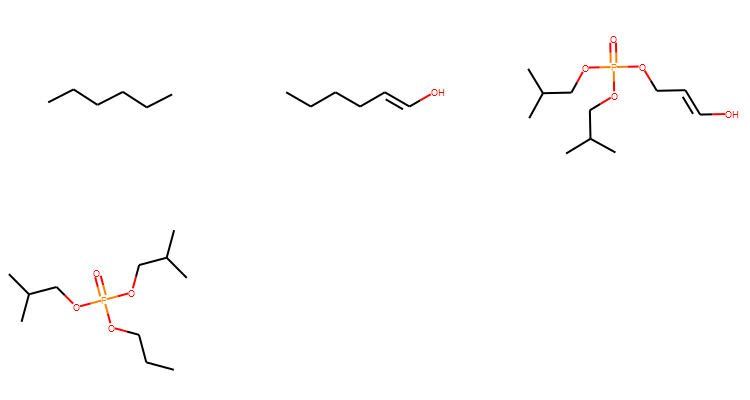

```python
#upload generated test data
enol_biowin = pd.read_csv((Projectdir + '\\selection\\enol_influence_biowin.txt'), sep="\t", header=None,
                          names=["Biowin1", "Biowin2","Biowin3", "Biowin4","Biowin5","Biowin6","Biowin7","SMILES"])
enol_logkow = pd.read_csv((Projectdir + '\\selection\\enol_influence_logkow.txt'), sep="\t", header=None,
                          names=["log Kow","SMILES"])
drawsmileslist(enol_biowin['SMILES'])
```

```python
enol_biowin = swaprowsdf(enol_biowin, 2,3)
enol_biowin.reset_index
enol_logkow = swaprowsdf(enol_logkow, 2,3)
enol_logkow.reset_index
```

```
<bound method DataFrame.reset_index of    log Kow                         SMILES
0     3.29                         CCCCCC
1     2.13                     CCCC/C=C/O
2     3.18    O=P(OCC(C)C)(OCC(C)C)OCC(C)
3     2.02  O=P(OC/C=C/O)(OCC(C)C)OCC(C)C>
```

For all Biowin results the molecule with the enol group has a higher (or equal 1) score.

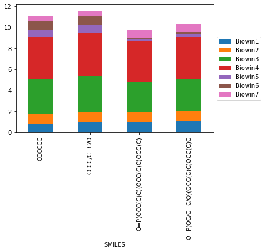

```python
#SMILES in graph: without - with enol - without - with enol
enol_biowin.plot(x= 'SMILES', kind='bar', stacked=True)
plt.legend(loc='center left', bbox_to_anchor=(1, 0.5))
```

```
Red line is threshold for persistency
```

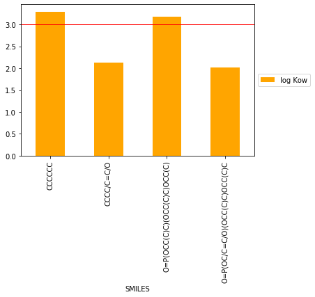

```python
#SMILES in graph: without - with enol - without - with enol
print('Red line is threshold for persistency')
enol_logkow.plot(x= 'SMILES', kind='bar', color = 'orange')
plt.legend(loc='center left', bbox_to_anchor=(1, 0.5))
plt.axhline(y=3,linewidth=1, color='red')
```

## DB influence

```python
DB_biowin = pd.read_csv((Projectdir + '\\selection\\DB_influencetargets_biowin.txt'), sep="\t", header=None,
                          names=["Biowin1", "Biowin2","Biowin3", "Biowin4","Biowin5","Biowin6","Biowin7","SMILES"])
DB_logkow = pd.read_csv((Projectdir + '\\selection\\DB_influencetargets_logkow.txt'), sep="\t", header=None,
                          names=["log Kow","SMILES"])
DB_mpbpvp = pd.read_csv((Projectdir + '\\selection\\DB_influencetargets_mpbpvp.txt'), sep="\t", header=None,
                          names=["bp degC",'mp degC','vp mmHg',"SMILES"])
DB_logkoc = pd.read_csv((Projectdir + '\\selection\\DB_influencetargets_koc.txt'), sep="\t", header=None,
                          names=["Koc","SMILES"])
DB_logkoc['log koc']= np.log10(DB_logkoc['Koc'])
del(DB_logkoc['Koc'])
DB_waternt = pd.read_csv((Projectdir + '\\selection\\DB_influencetargets_waternt.txt'), sep="\t", header=None,
                          names=["log WatSol mol/L", "WatSol mg/L", "SMILES"])
DB_wskowin = pd.read_csv((Projectdir + '\\selection\\DB_influencetargets_wskowin.txt'), sep="\t", header=None,
                          names=["WSol mg/L","log WSol mg/L", "SMILES"])
```

```python
DB_propsdfs = [DB_biowin, DB_logkow, DB_mpbpvp, DB_logkoc,DB_waternt, DB_wskowin]
DB_props = reduce(lambda left,right: pd.merge(left,right,on='SMILES'), DB_propsdfs)
DB_props['Names']= ['A','A no DB', 'B', 'B no DB']
DB_props.head()
```

|  | Biowin1 | Biowin2 | Biowin3 | Biowin4 | Biowin5 | Biowin6 | Biowin7 | SMILES | log Kow | bp degC | mp degC | vp mmHg | log koc | log WatSol mol/L | WatSol mg/L | WSol mg/L | log WSol mg/L | Names |
| --- | --- | --- | --- | --- | --- | --- | --- | --- | --- | --- | --- | --- | --- | --- | --- | --- | --- | --- |
| 0 | 1.2095 | 1.0 | 3.2582 | 4.3506 | 0.5756 | 0.4421 | 1.0009 | O=P1(OCC(O1)CCCCCC)O/C=C/O | 1.49 | 368.81 | 88.34 | 3.690000e-07 | 1.801747 | -2.2189 | 1511.7 | 1251 | 1.49 | A |
| 1 | 1.2086 | 1.0 | 3.2538 | 4.3477 | 0.6560 | 0.6251 | 1.1999 | O=P1(OCC(O1)CCCCCC)OCCO | 1.19 | 356.70 | 84.81 | 8.960000e-07 | 1.801747 | -0.9625 | 27502.0 | 7230 | 1.19 | A no DB |
| 2 | 1.2095 | 1.0 | 3.2582 | 4.3506 | 0.5193 | 0.2672 | 1.0548 | O=P1(OC(C(O1)CC)CCCC)O/C=C/O | 1.42 | 365.44 | 87.36 | 4.720000e-07 | 1.774955 | -2.2008 | 1575.9 | 1445 | 1.42 | B |
| 3 | 1.2086 | 1.0 | 3.2538 | 4.3477 | 0.5998 | 0.4342 | 1.2538 | O=P1(OCCO)OC(CCCC)C(CC)O1 | 1.11 | 353.34 | 83.83 | 1.150000e-06 | 1.774955 | -0.9444 | 28670.0 | 8354 | 1.11 | B no DB |

```
4 ready biodegradable molecules in table, out of  4 total
Ready biodegradable:
```

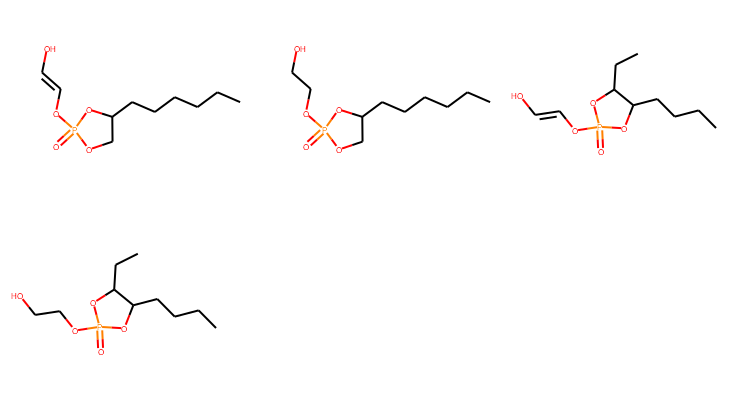

```python
ready_biodegradable_show(DB_props)
```

```python
#DB_props.to_csv('C:\\Users\\Hannah\\Documents\\Master UvA\\master project\\OMG\\selection\\DBinfluence_props.txt',
#                               header=True, index=True, sep='\t', mode='a')
```

```python
def addnames(df):
    df['Names']= ['A','A no DB', 'B', 'B no DB']

DBdfs = [DB_biowin, DB_logkow, DB_mpbpvp, DB_logkoc,DB_waternt, DB_wskowin]
for df in DBdfs:
    addnames(df)
```

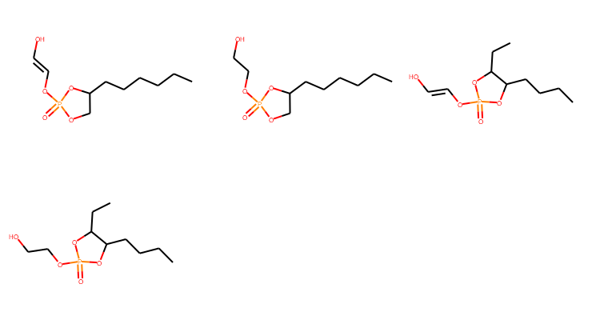

```python
drawsmileslist(DB_logkow['SMILES'])
```

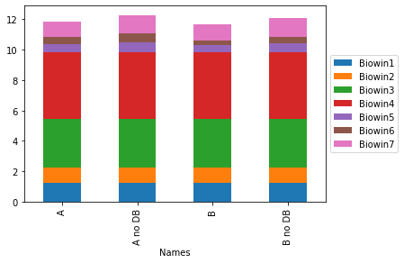

```python
DB_biowin.plot(x= 'Names', kind='bar', stacked=True)
plt.legend(loc='center left', bbox_to_anchor=(1, 0.5))
```

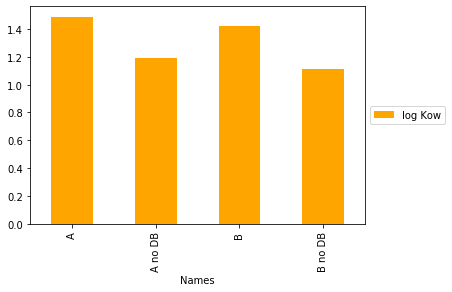

```python
DB_logkow.plot(x= 'Names', kind='bar', color = 'orange')
plt.legend(loc='center left', bbox_to_anchor=(1, 0.5))
#plt.axhline(y=3,linewidth=1, color='red')
```

```
0    3.690000e-07
1    8.960000e-07
2    4.720000e-07
3    1.150000e-06
Name: vp, dtype: float64
```

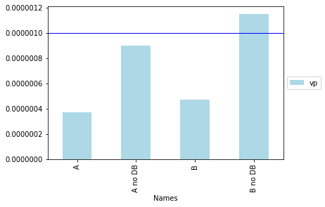

```python
print(DB_mpbpvp['vp'])
DB_mpbpvp[['Names','vp']].plot(x= 'Names', kind='bar', color = 'lightblue')
plt.legend(loc='center left', bbox_to_anchor=(1, 0.5))
#plt.axhline(y=(3.9E-5),linewidth=1, color='red') #upper volatility level
plt.axhline(y=(9.98E-7),linewidth=1, color='blue') #lower volatility level
```

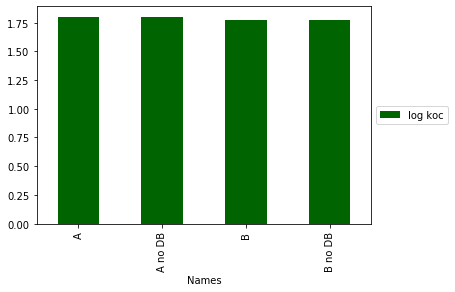

```python
DB_logkoc.plot(x= 'Names', kind='bar', color = 'darkgreen')
plt.legend(loc='center left', bbox_to_anchor=(1, 0.5))
```

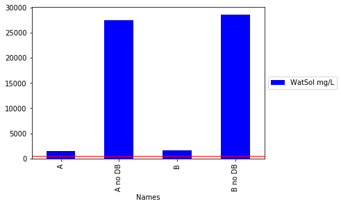

```python
DB_waternt.plot(x= 'Names',y= 'WatSol mg/L', kind='bar', color = 'blue')
plt.legend(loc='center left', bbox_to_anchor=(1, 0.5))
plt.axhline(y=(475),linewidth=1, color='red') #tibp solubility
```

```
0    16.22
Name: WSol mg/L, dtype: float64
```

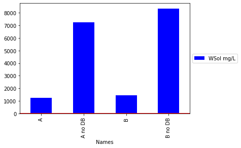

```python
DB_wskowin.plot(x= 'Names',y= 'WSol mg/L', kind='bar', color = 'blue')
plt.legend(loc='center left', bbox_to_anchor=(1, 0.5))
plt.axhline(y=(16.2),linewidth=1, color='red') #tibp solubility
tibp_allprops['WSol mg/L']
```